# 0.1 - Generating ‘Gravity Bookstore’ Dataset

George Melrose

30/05/2024

“*A database for a fictional bookstore called ”gravity” that captures information about books, customers, and sales.*.”

I used sqlite code from this github to generate the fake database - https://github.com/bbrumm/databasestar/tree/main/sample_databases/sample_db_gravity/sqlite

- book - a list of all books available in the store.
- book_author - stores the authors for each book, which is a many-to-many relationship.
- author - a list of all authors.
- book_language - a list of possible languages of books.
- publisher - a list of publishers for books.
- customer - a list of the customers of the Gravity Bookstore.
- customer_address - a list of addresses for customers, as a customer can have more than one address, and an address has more than one customer.
- address_status - a list of statuses for an address, because addresses can be current or old.
- address - a list of addresses in the system.
- country - a list of countries that addresses are in.
- cust_order - a list of orders placed by customers.
- order_line - a list of books that are a part of each order.
- shipping_method - the possible shipping methods for an order.
- order_history - the history of an order, such as ordered, cancelled, delivered.
- order_status - the possible statuses of an order.

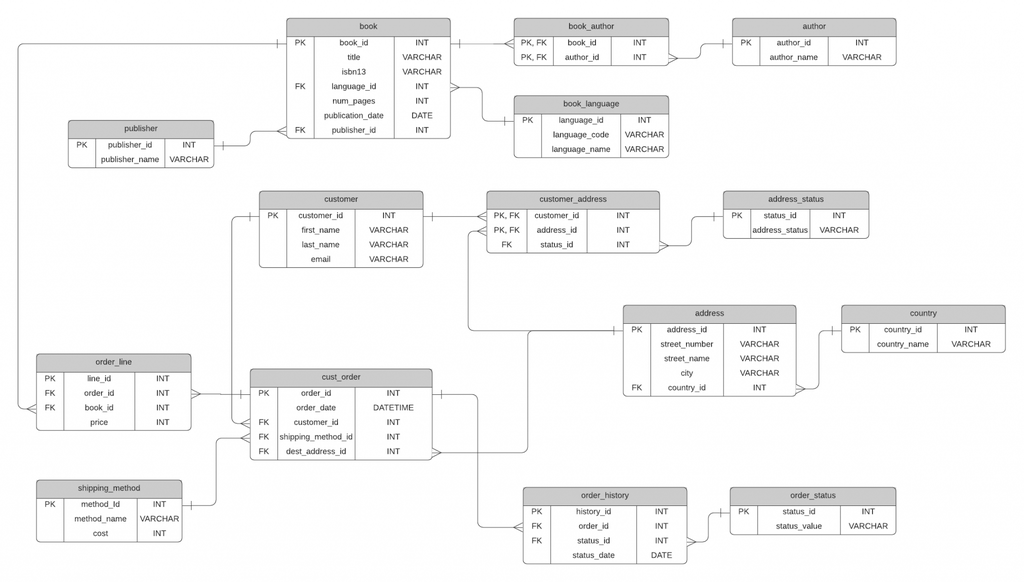

```r
knitr::include_graphics("C:/Users/gam55/Downloads/gravity_bookstore_erd.png")
```

```sql
CREATE TABLE author (
    author_id INTEGER PRIMARY KEY,
    author_name TEXT DEFAULT NULL
);
```

```sql
CREATE TABLE publisher (
    publisher_id INTEGER PRIMARY KEY,
    publisher_name TEXT
);
```

```sql
CREATE TABLE book_language (
    language_id INTEGER PRIMARY KEY,
    language_code TEXT,
    language_name TEXT
);
```

```sql
CREATE TABLE book (
    book_id INTEGER PRIMARY KEY,
    title TEXT,
    isbn13 TEXT,
    language_id INTEGER,
    num_pages INTEGER,
    publication_date DATE,
    publisher_id INTEGER,
    CONSTRAINT fk_book_lang FOREIGN KEY (language_id) REFERENCES book_language (language_id),
    CONSTRAINT fk_book_pub FOREIGN KEY (publisher_id) REFERENCES publisher (publisher_id)
);
```

```sql
CREATE TABLE book_author (
    book_id INTEGER NOT NULL,
    author_id INTEGER NOT NULL,
    CONSTRAINT pk_bookauthor PRIMARY KEY (book_id, author_id),
    CONSTRAINT fk_ba_book FOREIGN KEY (book_id) REFERENCES book (book_id),
    CONSTRAINT fk_ba_author FOREIGN KEY (author_id) REFERENCES author (author_id)
);
```

```sql
CREATE TABLE address_status (
    status_id INTEGER PRIMARY KEY,
    address_status TEXT
);
```

```sql
CREATE TABLE country (
    country_id INTEGER PRIMARY KEY,
    country_name TEXT
);
```

```sql
CREATE TABLE address (
    address_id INTEGER PRIMARY KEY,
    street_number TEXT,
    street_name TEXT,
    city TEXT,
    country_id INTEGER,
    CONSTRAINT fk_addr_ctry FOREIGN KEY (country_id) REFERENCES country (country_id)
);
```

```sql
CREATE TABLE customer (
    customer_id INTEGER PRIMARY KEY,
    first_name TEXT,
    last_name TEXT,
    email TEXT
);
```

```sql
CREATE TABLE customer_address (
    customer_id INTEGER NOT NULL,
    address_id INTEGER NOT NULL,
    status_id INTEGER,
    CONSTRAINT pk_custaddr PRIMARY KEY (customer_id, address_id),
    CONSTRAINT fk_ca_cust FOREIGN KEY (customer_id) REFERENCES customer (customer_id),
    CONSTRAINT fk_ca_addr FOREIGN KEY (address_id) REFERENCES address (address_id)
);
```

```sql
CREATE TABLE shipping_method (
    method_id INTEGER PRIMARY KEY,
    method_name TEXT,
    cost REAL
);
```

```sql
CREATE TABLE cust_order (
    order_id INTEGER PRIMARY KEY,
    order_date DATE,
    customer_id INTEGER,
    shipping_method_id INTEGER,
    dest_address_id INTEGER,
    CONSTRAINT fk_order_cust FOREIGN KEY (customer_id) REFERENCES customer (customer_id),
    CONSTRAINT fk_order_ship FOREIGN KEY (shipping_method_id) REFERENCES shipping_method (method_id),
    CONSTRAINT fk_order_addr FOREIGN KEY (dest_address_id) REFERENCES address (address_id)
);
```

```sql
CREATE TABLE order_status (
    status_id INTEGER PRIMARY KEY,
    status_value TEXT
);
```

```sql
CREATE TABLE order_line (
    line_id INTEGER PRIMARY KEY,
    order_id INTEGER,
    book_id INTEGER,
    price REAL,
    CONSTRAINT fk_ol_order FOREIGN KEY (order_id) REFERENCES cust_order (order_id),
    CONSTRAINT fk_ol_book FOREIGN KEY (book_id) REFERENCES book (book_id)
);
```

```sql
CREATE TABLE order_history (
    history_id INTEGER PRIMARY KEY,
    order_id INTEGER,
    status_id INTEGER,
    status_date DATE,
    CONSTRAINT fk_oh_order FOREIGN KEY (order_id) REFERENCES cust_order (order_id),
    CONSTRAINT fk_oh_status FOREIGN KEY (status_id) REFERENCES order_status (status_id)
);
```

```r
# List the tables present in the database connected through 'con'
tables <- dbListTables(con)

# Print the list of tables
print(tables)
```

```
##  [1] "address"          "address_status"   "author"           "book"
##  [5] "book_author"      "book_language"    "country"          "cust_order"
##  [9] "customer"         "customer_address" "order_history"    "order_line"
## [13] "order_status"     "publisher"        "shipping_method"
```

### Populating Author Table

```sql
INSERT INTO author (author_name, author_id) VALUES
('A. Bartlett Giamatti', 1),
('A. Elizabeth Delany', 2),
('A. Merritt', 3),
('A. Roger Merrill', 4),
('A. Walton Litz', 5),
('A.B. Yehoshua', 6),
('A.D.P. Briggs', 7),
('A.E. Cunningham', 8),
('A.E. van Vogt', 9),
('A.G. Pasquella', 10),
('A.H. Armstrong', 11),
('A.J. Arberry', 12),
('A.J. Ayer', 13),
('A.J. Jacobs', 14),
('A.J. McAllister', 15),
('A.M. Dellamonica', 16),
('A.M. Homes', 17),
('A.N. Roquelaure', 18),
('A.N. Wilson', 19),
('A.R. Braunmuller', 20),
('A.R. Taylor', 21),
('A.S. Byatt', 22),
('A.T. Hatto', 23),
('A.V. Miller', 24),
('Aaron Anderson', 25),
('Aaron Asher', 26),
('Aaron Medwin', 27),
('Aaron Rosenberg', 28),
('Aaron Shepard', 29),
('Abbe Wool', 30),
('Abbie Hoffman', 31),
('Abdul Rahman Munif', 32),
('Abdul-Karim Mustapha', 33),
('Abigail Adams', 34),
('Abigail Thomas', 35),
('Abolqasem Ferdowsi', 36),
('Abraham Lincoln', 37),
('Abraham Moore', 38),
('Adam Sexton', 39),
('Adam Drozdek', 40),
('Adam Gauntlett', 41),
('Adam Ginsberg', 42),
('Adam Golaski', 43),
('Adam Gopnik', 44),
('Adam Hargreaves', 45),
('Adam Haslett', 46),
('Adam Hochschild', 47),
('Adam Lesh', 48),
('Adam Long', 49),
('Adam Mansbach', 50),
('Adam Mars-Jones', 51),
('Adam McCauley', 52),
('Adam Phillips', 53),
('Adam Rex', 54),
('Adam Roberts', 55),
('Adam Smith', 56),
('Adam Swift', 57),
('Adam Woog', 58),
('Adam-Troy Castro', 59),
('Adela Pinch', 60),
('Adèle Geras', 61),
('Adèle Lang', 62),
('Adi Granov', 63),
('Adolfo Bioy Casares', 64),
('Adolfo Pérez Perdomo', 65),
('Adrian Reynolds', 66),
('Adrian Alphona', 67),
('Adrian Esteban', 68),
('Adrián Ferrero', 69),
('Adrian Geoffrey Gilbert', 70),
('Adrian Guelke', 71),
('Adrian Lester', 72),
('Adrian McKinty', 73),
('Adrian Wootton', 74),
('Adrienne Theimer', 75),
('Aeon J. Skoble', 76),
('Aeschylus', 77),
('Aesop', 78),
('Agatha Christie', 79),
('Agnes D. Kingston', 80),
('Agnolo di Cosimo Bronzino', 81),
('Ai Morinaga', 82),
('Aidan Hartley', 83),
('Aimé Césaire', 84),
('Aimee Bender', 85),
('Aimee Friedman', 86),
('Aine Greaney', 87),
('Akhil Sharma', 88),
('Akihiro Yamada', 89),
('Akira Watanabe', 90),
('Akira Yoshida', 91),
('Al Dempster', 92),
('Al Franken', 93),
('Al Gore', 94),
('Al Ries', 95),
('Al Rio', 96),
('Al Switzler', 97),
('Alafair Burke', 98),
('Alain de Botton', 99),
('Alain Defossé', 100),
('Alain Korkos', 101),
('Alak Zenkar', 102),
('Alan Lee', 103),
('Alan Aldridge', 104),
('Alan Brennert', 105),
('Alan Cohen', 106),
('Alan Dean Foster', 107),
('Alan Durband', 108),
('Alan Ereira', 109),
('Alan Greenspan', 110),
('Alan H. Sommerstein', 111),
('Alan Hausman', 112),
('Alan Hollinghurst', 113),
('Alan Jay Lerner', 114),
('Alan Jolis', 115),
('Alan Judd', 116),
('Alan Langford', 117),
('Alan Lightman', 118),
('Alan MacGillivray', 119),
('Alan Moore', 120),
('Alan Myers', 121),
('Alan Paton', 122),
('Alan R. Clarke', 123),
('Alan Rosenus', 124),
('Alan Shapiro', 125),
('Alan Witschonke', 126),
('Alastair Hamilton', 127),
('Alastair Hannay', 128),
('Alastair Lamb', 129),
('Alastair McEwen', 130),
('Alastair Reid', 131),
('Alastair Westgarth', 132),
('Albert Camus', 133),
('Albert Demeo', 134),
('Albert Einstein', 135),
('Albert Ellis', 136),
('Albert G. Spalding', 137),
('Albert Hackett', 138),
('Albert Hofstadter', 139),
('Albert Jack', 140),
('Albert Lee Strickland', 141),
('Albert Marrin', 142),
('Albert Speer', 143),
('Albert Wittstock', 144),
('Alberto Coscarelli', 145),
('Alcoholics Anonymous', 146),
('Alden T. Vaughan', 147),
('Aldon D. Morris', 148),
('Aldous Huxley', 149),
('Alec Effinger', 150),
('Alec MacLellan', 151),
('Alec Stevens', 152),
('Aleksandar Hemon', 153),
('Aleksandr Ivanovich Kuprin', 154),
('Aleksandr Solzhenitsyn', 155),
('Aleksey Ivanov', 156),
('Alev Lytle Croutier', 157),
('Alex Austin', 158),
('Alex C. Jones', 159),
('Alex Constantine', 160),
('Alex Cox', 161),
('Alex Garland', 162),
('Alex Gaskarth', 163),
('Alex Kava', 164),
('Alex Kershaw', 165),
('Alex Kotlowitz', 166),
('Alex Prud''Homme', 167),
('Alex Robinson', 168),
('Alex Ross', 169),
('Alex Went', 170),
('Alexander Walker', 171),
('Alexander C. Irvine', 172),
('Alexander Heidel', 173),
('Alexander Hunter', 174),
('Alexander McCall Smith', 175),
('Alexander Nehamas', 176),
('Alexander O. Smith', 177),
('Alexander Payne', 178),
('Alexander Pope', 179),
('Alexander Pushkin', 180),
('Alexander Scourby', 181),
('Alexander Theroux', 182),
('Alexandra Boiger', 183),
('Alexandra Ivy', 184),
('Alexandra Moss', 185),
('Alexandra Robbins', 186),
('Alexandra Siy', 187),
('Alexandra Wallner', 188),
('Alexandre Dumas', 189),
('Alexandre Dumas fils', 190),
('Alexis de Tocqueville', 191),
('Alexis Kirsch', 192),
('Alfred Appel', 193),
('Alfred Bester', 194),
('Alfred Birnbaum', 195),
('Alfred D. Chandler Jr.', 196),
('Alfred Hitchcock', 197),
('Alfred Huang', 198),
('Alfred J. Church', 199),
('Alfred Siewers', 200),
('Alfred Uhry', 201),
('Alfredo Crespo', 202),
('Algernon Blackwood', 203),
('Ali Douglass', 204),
('Ali Vali', 205),
('Alice Miller', 206),
('Alice Dalgliesh', 207),
('Alice Hoffman', 208),
('Alice Hudson', 209),
('Alice Kaplan', 210),
('Alice Mayhew', 211),
('Alice Medrich', 212),
('Alice Munro', 213),
('Alice Randall', 214),
('Alice Sebold', 215),
('Alice Walker', 216),
('Alice Wong', 217),
('Alicia Suskin Ostriker', 218),
('Alisa Freedman', 219),
('Alisa Klayman-Grodsky', 220),
('Alisa Valdes', 221),
('Alison Anderson', 222),
('Alison Baverstock', 223),
('Alison Bechdel', 224),
('Alison Boardman', 225),
('Alison Goodman', 226),
('Alison Kent', 227),
('Alison Leslie Gold', 228),
('Alison Lurie', 229),
('Alison Pace', 230),
('Alison Weir', 231),
('Alistair Horne', 232),
('Alistair MacLeod', 233),
('Alistair McCallum', 234),
('Alistair Moffat', 235),
('Alistair Welchman', 236),
('Alister E. McGrath', 237),
('Aljean Harmetz', 238),
('Allan Bloom', 239),
('Allan C. Weisbecker', 240),
('Allan Cameron', 241),
('Allan Curless', 242),
('Allan Drummond', 243),
('Allan Janik', 244),
('Allan Kozinn', 245),
('Allan Rosenberg', 246),
('Allan Ulrich', 247),
('Allan Zola Kronzek', 248),
('Allegra Goodman', 249),
('Allen Carr', 250),
('Allen Ginsberg', 251),
('Allen J. Frantzen', 252),
('Allen Mackey', 253),
('Allen Mandelbaum', 254),
('Allen Noren', 255),
('Allen Rogers Benner', 256),
('Allen W. Wood', 257),
('Allison Markin Powell', 258),
('Allison Pearson', 259),
('Alma Flor Ada', 260),
('Alma MacDougall Reising', 261),
('Alonzo C. Addison', 262),
('Alton Raible', 263),
('Alvin L. Reid', 264),
('Alyssa Harad', 265),
('Amanda Ann Klein', 266),
('Amanda Clark', 267),
('Amanda Eyre Ward', 268),
('Amanda Hemingway', 269),
('Amanda Hopkinson', 270),
('Amanda Root', 271),
('Amartya Sen', 272),
('Ambrose Bierce', 273),
('Amelia Atwater-Rhodes', 274),
('America''s Test Kitchen', 275),
('American Academy of Pediatrics', 276),
('Amiira Ruotola (-Behrendt)', 277),
('Amir D. Aczel', 278),
('Amiri Baraka', 279),
('Amitav Ghosh', 280),
('Amos Oz', 281),
('Amy Berner', 282),
('Amy Carter', 283),
('Amy Cotler', 284),
('Amy Goldman Koss', 285),
('Amy Gutmann', 286),
('Amy H. Sturgis', 287),
('Amy Hempel', 288),
('Amy Hill Hearth', 289),
('Amy Krouse Rosenthal', 290),
('Amy L. Marsland', 291),
('Amy Mandelker', 292),
('Amy Sedaris', 293),
('Amy Sickels', 294),
('Amy Sohn', 295),
('Amy Tan', 296),
('Amy Taubin', 297),
('Amy Welborn', 298),
('Ana Alcaina', 299),
('Ana Alcaina Pérez', 300),
('Ana Falcão Bastos', 301),
('Ana Juan', 302),
('Ana María de la Fuente', 303),
('Anaïs Nin', 304),
('Anaximander', 305),
('Anaximenes', 306),
('Anca Munteanu', 307),
('Ande Parks', 308),
('Anders Nilsen', 309),
('Anderson Cooper', 310),
('Andre Dubus', 311),
('Andre Dubus III', 312),
('Andre Duza', 313),
('André Maurois', 314),
('Andre Norton', 315),
('Andrea Camilleri', 316),
('Andrea Juno', 317),
('Andrea Levy', 318),
('Andrea Lingenfelter', 319),
('Andrea Wilson Nightingale', 320),
('Andreas Schwarz', 321),
('Andreas Gursky', 322),
('Andreas J. Köstenberger', 323),
('Andrei Codrescu', 324),
('Andrés Duany', 325),
('Andrew Hunt', 326),
('Andrew Hunt', 327),
('Andrew Brown', 328),
('Andrew Carnegie', 329),
('Andrew Cartmel', 330),
('Andrew Collins', 331),
('Andrew Darling', 332),
('Andrew Delbanco', 333),
('Andrew Dennis', 334),
('Andrew Edwin Jenkins', 335),
('Andrew Elfenbein', 336),
('Andrew Ford', 337),
('Andrew Glass', 338),
('Andrew Gross', 339),
('Andrew Gurr', 340),
('Andrew Heintzman', 341),
('Andrew Helfer', 342),
('Andrew Hurley', 343),
('Andrew Hussey', 344),
('Andrew J. Offutt', 345),
('Andrew James McLean', 346),
('Andrew Klavan', 347),
('Andrew Lang', 348),
('Andrew Leak', 349),
('Andrew M. Greeley', 350),
('Andrew McNeillie', 351),
('Andrew Moore', 352),
('Andrew O''Hagan', 353),
('Andrew P. Trout', 354),
('Andrew Pepoy', 355),
('Andrew R. MacAndrew', 356),
('Andrew Robert Burn', 357),
('Andrew S. Becker', 358),
('Andrew Scull', 359),
('Andrew Solomon', 360),
('Andrew Weil', 361),
('Andrew X. Pham', 362),
('Andy Crouch', 363),
('Andy Frankham-Allen', 364),
('Andy Gordon', 365),
('Andy Griffiths', 366),
('Andy Grundberg', 367),
('Andy Hertzfeld', 368),
('Andy Hunt', 369),
('Andy Kubert', 370),
('Andy Mastrocinque', 371),
('Andy McNab', 372),
('Andy Russell', 373),
('Andy Warhol', 374),
('Anette M. Pedersen', 375),
('Angel M.Y. Lin', 376),
('Angela Barrett', 377),
('Angela Carter', 378),
('Angela J. Linn', 379),
('Angela Knight', 380),
('Angela Scholar', 381),
('Angela Zeman', 382),
('Angelo Rinaldi', 383),
('Angus Easson', 384),
('Angus Gellatly', 385),
('Angus Wells', 386),
('Anita Desai', 387),
('Anita Diamant', 388),
('Anita Hoffman', 389),
('Anita Shreve', 390),
('Anita Thompson', 391),
('Anjali Singh', 392),
('Anjelica Huston', 393),
('Ann Douglas', 394),
('Ann O''Leary', 395),
('Ann Abramson', 396),
('Ann Bausum', 397),
('Ann Beattie', 398),
('Ann Brashares', 399),
('Ann Charters', 400),
('Ann Druyan', 401),
('Ann Dunnigan', 402),
('Ann Finding', 403),
('Ann Granger', 404),
('Ann Hewetson', 405),
('Ann Hodgman', 406),
('Ann M. Martin', 407),
('Ann Major', 408),
('Ann Margaret Lewis', 409),
('Ann Maxwell', 410),
('Ann McGovern', 411),
('Ann Packer', 412),
('Ann Page', 413),
('Ann Patchett', 414),
('Ann Rinaldi', 415),
('Ann Romines', 416),
('Ann Rule', 417),
('Ann Schweninger', 418),
('Ann Tashi Slater', 419),
('Ann Thompson', 420),
('Ann Thwaite', 421),
('Ann-Marie MacDonald', 422),
('Anna Austen Lefroy', 423),
('Anna Brailovsky', 424),
('Anna Deavere Smith', 425),
('Anna Fields', 426),
('Anna Hamilton Phelan', 427),
('Anna J.', 428),
('Anna J. Evans', 429),
('Anna Massey', 430),
('Anna Maxted', 431),
('Anna Moschovakis', 432),
('Anna Okabe', 433),
('Anna Paterson', 434),
('Anna Quindlen', 435),
('Anna Sewell', 436),
('Anna Tambour', 437),
('Anna Wintour', 438),
('Annalee Allen', 439),
('Annalyn Swan', 440),
('Anne Born', 441),
('Anne Borchardt', 442),
('Anne Brontë', 443),
('Anne Carson', 444),
('Anne Chisholm', 445),
('Anne Dehne', 446),
('Anne Easter Smith', 447),
('Anne Elizabeth Moore', 448),
('Anne Fadiman', 449),
('Anne Frank', 450),
('Anne Hoppus', 451),
('Anne K. Mellor', 452),
('Anne Lamott', 453),
('Anne Macdonald', 454),
('Anne Mazer', 455),
('Anne McCaffrey', 456),
('Anne McLean', 457),
('Anne Michaels', 458),
('Anne Millard', 459),
('Anne Moody', 460),
('Anne Morrow Lindbergh', 461),
('Anne Olivier Bell', 462),
('Anne Perry', 463),
('Anne Rampling', 464),
('Anne Rice', 465),
('Anne Stuart', 466),
('Anne Tyler', 467),
('Anne Yvonne Gilbert', 468),
('Anne-Marie Duff', 469),
('Anne-Marie Martin', 470),
('Annette Lavers', 471),
('Annette Meyers', 472),
('Annette Smith', 473),
('Annie Dillard', 474),
('Annie Proulx', 475),
('Annie Sparrow', 476),
('Anonymous', 477),
('Anri Itō', 478),
('Ansel Adams', 479),
('Anselm of Canterbury', 480),
('Anthea Bell', 481),
('Anthony Lewis', 482),
('Anthony Bonner', 483),
('Anthony Boucher', 484),
('Anthony Bourdain', 485),
('Anthony Bower', 486),
('Anthony Briggs', 487),
('Anthony Burgess', 488),
('Anthony Calderbank', 489),
('Anthony Cronin', 490),
```

```sql
('Anthony Curtis', 491),
('Anthony D. Pellegrini', 492),
('Anthony DeCurtis', 493),
('Anthony E. Wolf', 494),
('Anthony F.C. Wallace', 495),
('Anthony Gerard', 496),
('Anthony Grafton', 497),
('Anthony H. Chambers', 498),
('Anthony Heald', 499),
('Anthony Hern', 500),
('Anthony J. Cascardi', 501),
('Anthony Kenny', 502),
('Anthony Kerringan', 503),
('Anthony Kiedis', 504),
('Anthony Loyd', 505),
('Anthony M. Esolen', 506),
('Anthony Mcreavy', 507),
('Anthony Minghella', 508),
('Anthony Oldcorn', 509),
('Anthony Powell', 510),
('Anthony Quinton', 511),
('Anthony Richard Birley', 512),
('Anthony Rizcallah Ferris', 513),
('Anthony Robbins', 514),
('Anthony S. Fauci', 515),
('Anthony Shadid', 516),
('Anthony Thorlby', 517),
('Anthony Thwaite', 518),
('Anthony Tully', 519),
('Antoine de Saint-Exupéry', 520),
('Anton C. Pegis', 521),
('Anton Chekhov', 522),
('Anton Lesser', 523),
('Anton Myrer', 524),
('Antonia Fraser', 525),
('Antonia Juhasz', 526),
('Antonin Artaud', 527),
('Antonina W. Bouis', 528),
('Antonio Gramsci', 529),
('Antonio Negri', 530),
('Antonio Polito', 531),
('Antonio Samons', 532),
('Antony Beevor', 533),
('Antony Johnston', 534),
('Antony Shugaar', 535),
('Anya Seton', 536),
('Apollodorus', 537),
('Apostolos N. Athanassakis', 538),
('April Jones Prince', 539),
('Architecture For Humanity', 540),
('Ariel Levy', 541),
('Arielle Ford', 542),
('Arien Mack', 543),
('Aristophanes', 544),
('Aristotle', 545),
('Arkangel Cast', 546),
('Arlene Eisenberg', 547),
('Arliss Howard', 548),
('Armand Marie Leroi', 549),
('Armistead Maupin', 550),
('Arnold Gingrich', 551),
('Arnold Goldman', 552),
('Arnold Kotler', 553),
('Arnold Rampersad', 554),
('Arnold Vedlitz', 555),
('Arnon Grunberg', 556),
('Aron Eisenberg', 557),
('Art Cooper', 558),
('Art Spiegelman', 559),
('Art Spielman', 560),
('Art Thibert', 561),
('Artem Drabkin', 562),
('Artemis Cooper', 563),
('Arthur Miller', 564),
('Arthur Agatston', 565),
('Arthur Bennett', 566),
('Arthur C. Clarke', 567),
('Arthur Conan Doyle', 568),
('Arthur Cooper', 569),
('Arthur Doye', 570),
('Arthur Edward Waite', 571),
('Arthur G. Chater', 572),
('Arthur Golden', 573),
('Arthur Goldhammer', 574),
('Arthur H. Samuelson', 575),
('Arthur Herzog III', 576),
('Arthur J. Roth', 577),
('Arthur Knodel', 578),
('Arthur Koestler', 579),
('Arthur M. Schlesinger Jr.', 580),
('Arthur Machen', 581),
('Arthur Morey', 582),
('Arthur Naiman', 583),
('Arthur Nersesian', 584),
('Arthur P. Yin', 585),
('Arthur Plotnik', 586),
('Arthur Pober', 587),
('Arthur Rackham', 588),
('Arthur Raleigh Humphreys', 589),
('Arthur S. Wensinger', 590),
('Arthur Schopenhauer', 591),
('Arthur Yorinks', 592),
('Artists and Writers Guild', 593),
('Arto Häilä', 594),
('Arturo Pérez-Reverte', 595),
('Arundhati Roy', 596),
('Ashley Gardner', 597),
('Ashley Shannon', 598),
('Ashley Wood', 599),
('Åsne Seierstad', 600),
('Astre Mithrandir', 601),
('Astrid Lindgren', 602),
('Atul Gawande', 603),
('Aubrey de Sélincourt', 604),
('Aubrey Williams', 605),
('Audre Lorde', 606),
('Audrey Niffenegger', 607),
('Audrey Penn', 608),
('August Derleth', 609),
('August Wilson', 610),
('Augusten Burroughs', 611),
('Augustine of Hippo', 612),
('Aurelio Voltaire', 613),
('Aurora Echevarría', 614),
('Austin Tichenor', 615),
('Avatar Polymorph', 616),
('Avi', 617),
('Avigdor Kahalani', 618),
('Avrahm Yarmolinsky', 619),
('Ayako Watanabe', 620),
('Aylmer Maude', 621),
('Ayn Rand', 622),
('Azar Nafisi', 623),
('Azzedine Haddour', 624),
('B. Deutsch', 625),
('B. Litt', 626),
('B.B. Rogers', 627),
('B.C.J.G. Knight', 628),
('B.J. McCall', 629),
('B.K. Beckwith', 630),
('Babette Rothschild', 631),
('Babette Smith', 632),
('Bagram Ibatoulline', 633),
('Baillie Tolkien', 634),
('Bambi Eloriaga', 635),
('Barack Obama', 636),
('Barb Jernigan', 637),
('Barbara Newman', 638),
('Barbara A. Mowat', 639),
('Barbara A. Turner', 640),
('Barbara Ann Brennan', 641),
('Barbara Berst Adams', 642),
('Barbara Bottner', 643),
('Barbara Bray', 644),
('Barbara Bretton', 645),
('Barbara Caruso', 646),
('Barbara Cleverly', 647),
('Barbara Cohen', 648),
('Barbara Coloroso', 649),
('Barbara Conklin', 650),
('Barbara Cooney', 651),
('Barbara Davilman', 652),
('Barbara Delaplace', 653),
('Barbara E. Martin', 654),
('Barbara Ehrenreich', 655),
('Barbara Fairchild', 656),
('Barbara Hambly', 657),
('Barbara Haworth-Attard', 658),
('Barbara Kerley', 659),
('Barbara Kingsolver', 660),
('Barbara Leonie Picard', 661),
('Barbara M. Walker', 662),
('Barbara Nadel', 663),
('Barbara Park', 664),
('Barbara Reynolds', 665),
('Barbara Richard', 666),
('Barbara Siegel', 667),
('Barbara Smuts', 668),
('Barbara T. Cooper', 669),
('Barbara Taylor Bradford', 670),
('Barbara W. Tuchman', 671),
('Barbara Weiden Boyd', 672),
('Barbara Wright', 673),
('Bard E. O''Neill', 674),
('Bard Thompson', 675),
('Barney Tobey', 676),
('Barrett Whitener', 677),
('Barrie D. Coate', 678),
('Barrie Trinkle', 679),
('Barrington Moore Jr.', 680),
('Barron''s', 681),
('Barry Lopez', 682),
('Barry Smith', 683),
('Barry Chubin', 684),
('Barry Day', 685),
('Barry Eisler', 686),
('Barry Glassner', 687),
('Barry Hughart', 688),
('Barry M. Andrews', 689),
('Barry Menikoff', 690),
('Barry Miles', 691),
('Barry Moser', 692),
('Barry N. Malzberg', 693),
('Barry Pateman', 694),
('Barry R. Cournoyer', 695),
('Barry Schwartz', 696),
('Barry Z. Posner', 697),
('Bart D. Ehrman', 698),
('Bart G. Farkas', 699),
('Bart King', 700),
('Barthe DeClements', 701),
('Bartholomew Gill', 702),
('Barton Zwiebach', 703),
('Baruch Spinoza', 704),
('Basil Mahon', 705),
('Basil Pao', 706),
('Basilio Losada', 707),
('Bathroom Readers'' Institute', 708),
('Be-Papas', 709),
('Be-Pas', 710),
('Beatrix Potter', 711),
('Beau Bridges', 712),
('Bebe Moore Campbell', 713),
('Becky Ann Baker', 714),
('bell hooks', 715),
('Belva Plain', 716),
('Ben Avery', 717),
('Ben Bova', 718),
('Ben Carson', 719),
('Ben Counter', 720),
('Ben Elton', 721),
('Ben Katchor', 722),
('Ben M. Baglio', 723),
('Ben Marcus', 724),
('Ben Mezrich', 725),
('Ben Mikaelsen', 726),
('Ben Ohlander', 727),
('Ben Oliver', 728),
('Ben R. Kaplan', 729),
('Ben Schoen', 730),
('Ben Schott', 731),
('Ben Shahn', 732),
('Ben Templesmith', 733),
('Ben Wasson', 734),
('Benjamin Beard', 735),
('Benjamin Chaud', 736),
('Benjamin DeMott', 737),
('Benjamin F. Fisher', 738),
('Benjamin James Sadock', 739),
('Benjamin Jowett', 740),
('Benjamin Martinez', 741),
('Bennett Cerf', 742),
('Bentley Little', 743),
('Berlitz Publishing Company', 744),
('Bernard Bador', 745),
('Bernard Cohen', 746),
('Bernard Cornwell', 747),
('Bernard DeVoto', 748),
('Bernard Frechtman', 749),
('Bernard Knox', 750),
('Bernard Lewis', 751),
('Bernard Malamud', 752),
('Bernard Taper', 753),
('Bernard Williams', 754),
('Bernd Matzkowski', 755),
('Bernice Kert', 756),
('Bernie Wrightson', 757),
('Bert G. Hornback', 758),
('Berta Platas', 759),
('Bertrand Russell', 760),
('Beryl Bainbridge', 761),
('Beryl Markham', 762),
('Bessie Head', 763),
('Beth A. Jones', 764),
('Beth Chaplin', 765),
('Beth Cuthand', 766),
('Beth Dunfey', 767),
('Beth Hensperger', 768),
('Beth Kendrick', 769),
('Beth Moore', 770),
('Bethany Roberts', 771),
('Betina Ogden', 772),
('Betsy Lewin', 773),
('Bette Greene', 774),
('Better Homes and Gardens', 775),
('Bettina Blanch Tyroller', 776),
('Betty Smith', 777),
('Betty David', 778),
('Betty Friedan', 779),
('Betty Jay', 780),
('Betty MacDonald', 781),
('Betty Mahmoody', 782),
('Betty McCollum', 783),
('Betty Neels', 784),
('Betty Radice', 785),
('Bev Vincent', 786),
('Beverly Cleary', 787),
('Beverly Daniel Tatum', 788),
('Bianca Southwood', 789),
('Bill Phillips', 790),
('Bill Bryson', 791),
('Bill Bettencourt', 792),
('Bill Brittain', 793),
('Bill Brown', 794),
('Bill Bryson', 795),
('Bill Buford', 796),
('Bill Clinton', 797),
('Bill Cosby', 798),
('Bill Dodge', 799),
('Bill Farrel', 800),
('Bill Fawcett', 801),
('Bill Gardner', 802),
('Bill Hurter', 803),
('Bill Hybels', 804),
('Bill Irwin', 805),
('Bill Johnston', 806),
('Bill Maher', 807),
('Bill Miller', 808),
('Bill Moyers', 809),
('Bill Nichols', 810),
('Bill Phillips', 811),
('Bill Pittman', 812),
('Bill Plaschke', 813),
('Bill Potter', 814),
('Bill Pronzini', 815),
('Bill Richardson', 816),
('Bill Robertie', 817),
('Bill Sienkiewicz', 818),
('Bill Veeck', 819),
('Bill Watterson', 820),
('Bill Willingham', 821),
('Bill Wittliff', 822),
('Billie Letts', 823),
('Billy Collins', 824),
('Billy Crystal', 825),
('Billy Goldberg', 826),
('Billy Merrell', 827),
('Billy Mills', 828),
('Billy Wilder', 829),
('Binjamin W. Segel', 830),
('Birgit Brandau', 831),
('Black Elk', 832),
('Blaine M. Yorgason', 833),
('Blair Brown', 834),
('Blaise Pascal', 835),
('Blake Cahoon', 836),
('Blake Morrison', 837),
('Blake Nelson', 838),
('Blake Nevius', 839),
('Blanca Ríos', 840),
('Bob Smith', 841),
('Bob Blaisdell', 842),
('Bob Carrau', 843),
('Bob Colacello', 844),
('Bob Cullen', 845),
('Bob Dylan', 846),
('Bob Haney', 847),
('Bob Hines', 848),
('Bob Lappan', 849),
('Bob Madgic', 850),
('Bob Marley', 851),
('Bob McCabe', 852),
('Bob McLeod', 853),
('Bob Phillips', 854),
('Bob Shaw', 855),
('Bob Spitz', 856),
('Bob Tarte', 857),
('Bob Walters', 858),
('Bob Woodward', 859),
('Bobbi Smith', 860),
('Bobby Baldwin', 861),
('Bobby Flay', 862),
('Bobby Henderson', 863),
('Bodie Thoene', 864),
('Boethius', 865),
('Boniface Ramsey', 866),
('Bonnie Burton', 867),
('Bonnie Kime Scott', 868),
('Bonnie Lisle', 869),
('Bonnie Mackain', 870),
('Bonnie Timmons', 871),
('Borden Deal', 872),
('Boris Grabnar', 873),
('Boris Pasternak', 874),
('Boris Vian', 875),
('Brad Inwood', 876),
('Brad Leithauser', 877),
('Brad Meltzer', 878),
('Brad Thor', 879),
('Brad Walker', 880),
('Brady Games', 881),
('Bram Stoker', 882),
('Brandon Badeaux', 883),
('Brandon Mull', 884),
('Brantley Johnson', 885),
('Brenda Cooper', 886),
('Brenda G. Bare', 887),
('Brenda Jackson', 888),
('Brenda Joyce', 889),
('Brenda K. Marshall', 890),
('Brenda Novak', 891),
('Brenda Walpole', 892),
('Brendan Connell', 893),
('Brendan DuBois', 894),
('Brendan Frayne', 895),
('Brendan Gill', 896),
('Brent Hoff', 897),
('Brenton G. Yorgason', 898),
('Breon Mitchell', 899),
('Bret Easton Ellis', 900),
('Bret Norris', 901),
('Brett Booth', 902),
('Brett Hartinge', 903),
('Brian Doyle', 904),
('Brian Nelson', 905),
('Brian Phillips', 906),
('Brian Wood', 907),
('Brian Ajhar', 908),
('Brian Antoni', 909),
('Brian Azzarello', 910),
('Brian Bolland', 911),
('Brian Boyd', 912),
('Brian Braithwaite', 913),
('Brian Campbell', 914),
('Brian Ching', 915),
('Brian Copeland', 916),
('Brian D. McLaren', 917),
('Brian Doherty', 918),
('Brian Floca', 919),
('Brian Greene', 920),
('Brian Hall', 921),
('Brian Herbert', 922),
('Brian Hooker', 923),
('Brian J. Robb', 924),
('Brian Jacques', 925),
('Brian James', 926),
('Brian James Freeman', 927),
('Brian Johnston', 928),
('Brian K. Vaughan', 929),
('Brian L. Weiss', 930),
('Brian M. Sammons', 931),
('Brian McGuinness', 932),
('Brian McNaughton', 933),
('Brian Michael Bendis', 934),
('Brian Nishil', 935),
('Brian P. Flannery', 936),
('Brian Rotman', 937),
('Brian Selznick', 938),
('Brian Sibley', 939),
('Brian Stableford', 940),
('Brian Stone', 941),
('Brian Tracy', 942),
('Brian Troxell', 943),
('Brian Unger', 944),
('Brian W. Aldiss', 945),
('Brian Yoon', 946),
('Brice Matthieussent', 947),
('Bridget Foley', 948),
('Brigid Avison', 949),
('Brigitte Lefevre', 950),
('Brion Gysin', 951),
('Brittiany A. Koren', 952),
('Brock Thoene', 953),
('Brooke Allen', 954),
('Broughton Coburn', 955),
('Brown', 956),
('Bruce Alvin King', 957),
('Bruce Arnold', 958),
('Bruce Bethke', 959),
('Bruce Campbell', 960),
('Bruce Catton', 961),
('Bruce Coville', 962),
('Bruce Cumings', 963),
('Bruce Degen', 964),
('Bruce E. Bursten', 965),
('Bruce Edward Walker', 966),
('Bruce Feiler', 967),
('Bruce H. Wilkinson', 968),
('Bruce Harbert', 969),
('Bruce Holland Rogers', 970),
('Bruce Kuklick', 971),
('Bruce L. Edwards', 972),
('Bruce Patton', 973),
('Bruce Rogers', 974),
('Bruce Spizer', 975),
```

```sql
('Bruce Sterling', 976),
('Bryan Collier', 977),
('Bryan Hitch', 978),
('Bryan J.L. Glass', 979),
('Bryan Lee O''Malley', 980),
('Bryan Magee', 981),
('Bryan Sykes', 982),
('Bryan Talbot', 983),
('Bryan W. Van Norden', 984),
('Bryce Courtenay', 985),
('Buchi Emecheta', 986),
('Buck Schirner', 987),
('Burt Reynolds', 988);
```

```sql
INSERT INTO author (author_name, author_id) VALUES
('Burton G. Malkiel', 989),
('Burton Pike', 990),
('Burton Raffel', 991),
('Butch Patrick', 992),
('Buzz Aldrin', 993),
('Buzz Bissinger', 994),
('C. Hassell Bullock', 995),
('C. Michael Dudash', 996),
('C. Patrick Doncaster', 997),
('C. Thomas Wass', 998),
('C. Vann Woodward', 999),
('C.B. Cebulski', 1000),
('C.B. Mordan', 1001),
('C.D. Payne', 1002),
('C.D.B. Bryan', 1003),
('C.D.C. Reeve', 1004),
('C.E. Murphy', 1005),
('C.F. Smith', 1006),
('C.G. Jung', 1007),
('C.H. Sisson', 1008),
('C.J. Cherryh', 1009),
('C.J. Critt', 1010),
('C.J. Friedrich', 1011),
('C.J. Henderson', 1012),
('C.J. Rowe', 1013),
('C.K. Scott Moncrieff', 1014),
('C.L. Moore', 1015),
('C.M. Kornbluth', 1016),
('C.P. Otero', 1017),
('C.S. Friedman', 1018),
('C.S. Harris', 1019),
('C.S. Lewis', 1020),
('C.W. Scott-Giles', 1021),
('Cait London', 1022),
('Caitlin Brennan', 1023),
('Caitlín R. Kiernan', 1024),
('Caldwell B. Esselstyn Jr.', 1025),
('Caleb Carr', 1026),
('Călin-Andrei Mihăilescu', 1027),
('Camellia Panjabi', 1028),
('Cameron Sinclair', 1029),
('Cameron Stewart', 1030),
('Camila Batlles', 1031),
('Camille Cauti', 1032),
('Camille Kingsolver', 1033),
('Camino Estañ Requeni', 1034),
('Campbell Scott', 1035),
('Candace Bushnell', 1036),
('Candace Schuler', 1037),
('Candace Ward', 1038),
('Candida Höfer', 1039),
('Canon Doyle', 1040),
('Cao Xuân Việt Khương', 1041),
('Cara Black', 1042),
('Cara Lockwood', 1043),
('Cara Williams', 1044),
('Carl Barks', 1045),
('Carl Bode', 1046),
('Carl Dennis', 1047),
('Carl Ellis', 1048),
('Carl F. Hovde', 1049),
('Carl F.H. Henry', 1050),
('Carl Gustav Horn', 1051),
('Carl Hiaasen', 1052),
('Carl Joachim Friedrich', 1053),
('Carl Plasa', 1054),
('Carl Safina', 1055),
('Carl Sagan', 1056),
('Carl Sandburg', 1057),
('Carl Senna', 1058),
('Carl Zimmer', 1059),
('Carla Jungquist', 1060),
('Carla Kaplan', 1061),
('Carla Lynn Stockton', 1062),
('Carlene Fredericka Brennen', 1063),
('Carlo Capararo', 1064),
('Carlos A. Schwantes', 1065),
('Carlos Alberto Gardini', 1066),
('Carlos Castañeda', 1067),
('Carlos Fuentes', 1068),
('Carlos Garzon', 1069),
('Carlos Marighella', 1070),
('Carlos Martín Ramírez', 1071),
('Carlos Meglia', 1072),
('Carlos Milla Soler', 1073),
('Carlos Ruiz Zafón', 1074),
('Carlton Mellick III', 1075),
('Carme Camps Monf', 1076),
('Carmelina Payá', 1077),
('Carol Adrienne', 1078),
('Carol Belanger Grafton', 1079),
('Carol Bloom Stevens', 1080),
('Carol C. Haber', 1081),
('Carol Christensen', 1082),
('Carol Cosman', 1083),
('Carol Dommermuth-Costa', 1084),
('Carol Drinkwater', 1085),
('Carol Emshwiller', 1086),
('Carol Heyer', 1087),
('Carol Higgins Clark', 1088),
('Carol Howard', 1089),
('Carol Kolb', 1090),
('Carol Lee', 1091),
('Carol Lloyd', 1092),
('Carol Marinelli', 1093),
('Carol McGreal', 1094),
('Carol Phillips', 1095),
('Carol Rondou', 1096),
('Carol Ryrie Brink', 1097),
('Carol Shields', 1098),
('Carol Stock Kranowitz', 1099),
('Carol T. Christ', 1100),
('Carole Marsh', 1101),
('Carole Matthews', 1102),
('Carole Nelson Douglas', 1103),
('Carolina Hospital', 1104),
('Caroline Austen', 1105),
('Caroline B. Cooney', 1106),
('Caroline Denzler', 1107),
('Caroline Fitzgerald', 1108),
('Caroline Preston', 1109),
('Caroline Sharp', 1110),
('Carolly Erickson', 1111),
('Carolyn Andrews', 1112),
('Carolyn Brown', 1113),
('Carolyn Dewald', 1114),
('Carolyn G. Heilbrun', 1115),
('Carolyn Haywood', 1116),
('Carolyn Keene', 1117),
('Carolyn Korsmeyer', 1118),
('Carolyn L. Gegor', 1119),
('Carolyn McCarthy', 1120),
('Carolyn McCormick', 1121),
('Carolyn Meyer', 1122),
('Carolyn Strom Collins', 1123),
('Carolyn Wheat', 1124),
('Carrie Channell', 1125),
('Carrie Vaughn', 1126),
('Carroll John Daly', 1127),
('Carson McCullers', 1128),
('Cary F. Baynes', 1129),
('Caryl Emerson', 1130),
('Casey Loe', 1131),
('Cassandra Austen', 1132),
('Cassandra Campbell', 1133),
('Catharine M. Fishel', 1134),
('Catharine Peters', 1135),
('Catherine Johnson', 1136),
('Catherine Camus', 1137),
('Catherine Chaine', 1138),
('Catherine Cobham', 1139),
('Catherine Coulter', 1140),
('Catherine de Zegher', 1141),
('Catherine Foley', 1142),
('Catherine Gilbert Murdock', 1143),
('Catherine Hapka', 1144),
('Catherine Hutter', 1145),
('Catherine Liu', 1146),
('Catherine Marshall', 1147),
('Catherine Nichols', 1148),
('Catherine Osborne', 1149),
('Catherine Spencer', 1150),
('Catherine Thimmesh', 1151),
('Catherine Whitney', 1152),
('Catherynne M. Valente', 1153),
('Cathleen Miller', 1154),
('Cathy Kelly', 1155),
('Cecelia Ahern', 1156),
('Cecil Adams', 1157),
('Cecil Day-Lewis', 1158),
('Cecil Hemley', 1159),
('Cecil Maurice Bowra', 1160),
('Cecil Murphey', 1161),
('Cecily von Ziegesar', 1162),
('Cedric Belfrage', 1163),
('Cedric Watts', 1164),
('Celeste Bradley', 1165),
('Celeste Davidson Mannis', 1166),
('Cesare Beccaria', 1167),
('Chad Fowler', 1168),
('Chad Oliver', 1169),
('Chaim Potok', 1170),
('Chalmers Johnson', 1171),
('Chandler Brossard', 1172),
('Chanrithy Him', 1173),
('Chantal Mouffe', 1174),
('Chaosium Inc.', 1175),
('Charlaine Harris', 1176),
('Charlee Jacob', 1177),
('Charles Martin', 1178),
('Charles Johnson', 1179),
('Charles Wilson', 1180),
('Charles Green', 1181),
('Charles Lee', 1182),
('Charles A. Coulombe', 1183),
('Charles A. Peek', 1184),
('Charles Alexander Moore', 1185),
('Charles Alexander Robinson Jr.', 1186),
('Charles Allen', 1187),
('Charles Baudelaire', 1188),
('Charles Baxter', 1189),
('Charles Bowden', 1190),
('Charles Boyce', 1191),
('Charles Bukowski', 1192),
('Charles Burns', 1193),
('Charles C. Mann', 1194),
('Charles Coulston Gillispie', 1195),
('Charles Darwin', 1196),
('Charles de Lint', 1197),
('Charles Dickens', 1198),
('Charles E. Wilbour', 1199),
('Charles F. Miller', 1200),
('Charles Fanning', 1201),
('Charles Flowers', 1202),
('Charles Frazier', 1203),
('Charles G. Waugh', 1204),
('Charles Guignon', 1205),
('Charles H. Wilson', 1206),
('Charles Hegel', 1207),
('Charles Hirshberg', 1208),
('Charles J. Sykes', 1209),
('Charles John Cutcliffe Wright Hyne', 1210),
('Charles Johnston', 1211),
('Charles Keegan', 1212),
('Charles Kingsley', 1213),
('Charles Lamb', 1214),
('Charles Larson', 1215),
('Charles Lockwood', 1216),
('Charles M. Schulz', 1217),
('Charles Mackay', 1218),
('Charles Marowitz', 1219),
('Charles McKeown', 1220),
('Charles Moore', 1221),
('Charles Neider', 1222),
('Charles Osborne', 1223),
('Charles P. Rubenstein', 1224),
('Charles P. Zaglanis', 1225),
('Charles Petzold', 1226),
('Charles R. Forker', 1227),
('Charles R. Johnson', 1228),
('Charles R. Miller', 1229),
('Charles R. Smith Jr.', 1230),
('Charles R. Swindoll', 1231),
('Charles R. Walker', 1232),
('Charles Rembar', 1233),
('Charles S. Anderson Design Company', 1234),
('Charles Scribner Jr.', 1235),
('Charles Segal', 1236),
('Charles Seife', 1237),
('Charles Simic', 1238),
('Charles Stross', 1239),
('Charles Tandy', 1240),
('Charles Tang', 1241),
('Charles Taylor', 1242),
('Charles Todd', 1243),
('Charles Tomlinson', 1244),
('Charles Vess', 1245),
('Charles W. Sydnor Jr.', 1246),
('Charles Wheelan', 1247),
('Charles Willeford', 1248),
('Charley Boorman', 1249),
('Charlie Adlard', 1250),
('Charlie Conrad', 1251),
('Charlie Huston', 1252),
('Charlie O''Neill', 1253),
('Charlotte Brontë', 1254),
('Charlotte Fiell', 1255),
('Charlotte Hughes', 1256),
('Charlotte Lyons', 1257),
('Charlotte Mitchell', 1258),
('Charlotte Perkins Gilman', 1259),
('Charlton Heston', 1260),
('Chase Hensel', 1261),
('Cheri Huber', 1262),
('Cherry Jones', 1263),
('Cheryl A. Wall', 1264),
('Cheryl Carlson', 1265),
('Cheryl Henson', 1266),
('Cheryl St. John', 1267),
('Cheryl Walker', 1268),
('Chester Gould', 1269),
('Chester Himes', 1270),
('Chet Green', 1271),
('Chie Shinohara', 1272),
('Chieri Uegaki', 1273),
('Chiho Saito', 1274),
('Chimamanda Ngozi Adichie', 1275),
('China Miéville', 1276),
('Chinua Achebe', 1277),
('Chip Kidd', 1278),
('Chris Jones', 1279),
('Chris Turner', 1280),
('Chris Green', 1281),
('Chris Scott', 1282),
('Chris Smith', 1283),
('Chris Williams', 1284),
('Chris Abani', 1285),
('Chris Adrian', 1286),
('Chris Anderson', 1287),
('Chris Andrews', 1288),
('Chris Archer', 1289),
('Chris Bachalo', 1290),
('Chris Brunner', 1291),
('Chris Chester', 1292),
('Chris Claremont', 1293),
('Chris Emlyn-Jones', 1294),
('Chris Fabry', 1295),
('Chris Gardner', 1296),
('Chris Garratt', 1297),
('Chris Gray', 1298),
('Chris Horrocks', 1299),
('Chris Ingham', 1300),
('Chris Kubica', 1301),
('Chris L. Demarest', 1302),
('Chris Malta', 1303),
('Chris Manby', 1304),
('Chris McCubbin', 1305),
('Chris Miller', 1306),
('Chris Mooney', 1307),
('Chris Noth', 1308),
('Chris Offutt', 1309),
('Chris Pierson', 1310),
('Chris Pitzer', 1311),
('Chris Pratley', 1312),
('Chris Prentiss', 1313),
('Chris R. Dickman', 1314),
('Chris Raschka', 1315),
('Chris Riddell', 1316),
('Chris Rowthorn', 1317),
('Chris Ryall', 1318),
('Chris Sabatino', 1319),
('Chris Seay', 1320),
('Chris Sheban', 1321),
('Chris Tait', 1322),
('Chris Terry', 1323),
('Chris Trevas', 1324),
('Chris Van Allsburg', 1325),
('Chris Van Dusen', 1326),
('Chris Ware', 1327),
('Chris Weston', 1328),
('Chris Wooding', 1329),
('Chris Wright', 1330),
('Chris Wrigley', 1331),
('Chrissie Zullo', 1332),
('Christa Jansohn', 1333),
('Christa Seibicke', 1334),
('Christian Birmingham', 1335),
('Christian Bonacic', 1336),
('Christian Dalla Vecchia', 1337),
('Christiane Northrup', 1338),
('Christie Ridgway', 1339),
('Christina Dodd', 1340),
('Christina F. York', 1341),
('Christina Grof', 1342),
('Christina Schwarz', 1343),
('Christina Scull', 1344),
('Christina Wyss Eriksson', 1345),
('Christine Feehan', 1346),
('Christine Filipak', 1347),
('Christine Rimmer', 1348),
('Christophe Claro', 1349),
('Christopher Black', 1350),
('Christopher Clark', 1351),
('Christopher Duncan', 1352),
('Christopher Green', 1353),
('Christopher Lee', 1354),
('Christopher Rice', 1355),
('Christopher Andersen', 1356),
('Christopher Barzak', 1357),
('Christopher Biffle', 1358),
('Christopher Bigsby', 1359),
('Christopher Bram', 1360),
('Christopher Buckley', 1361),
('Christopher Caswell', 1362),
('Christopher Cerf', 1363),
('Christopher Cokinos', 1364),
('Christopher Collier', 1365),
('Christopher Corr', 1366),
('Christopher Denise', 1367),
('Christopher E.G. Benfey', 1368),
('Christopher Flavin', 1369),
('Christopher Fowler', 1370),
('Christopher Gill', 1371),
('Christopher Golden', 1372),
('Christopher H. Bing', 1373),
('Christopher Hirsheimer', 1374),
('Christopher Hitchens', 1375),
('Christopher Hurt', 1376),
('Christopher Isherwood', 1377),
('Christopher J. Phoenix', 1378),
('Christopher Janaway', 1379),
('Christopher Krovatin', 1380),
('Christopher Lane', 1381),
('Christopher M. Andrew', 1382),
('Christopher Marlowe', 1383),
('Christopher Maurer', 1384),
('Christopher Mitten', 1385),
('Christopher Moore', 1386),
('Christopher Partridge', 1387),
('Christopher Pike', 1388),
('Christopher Pinney', 1389),
('Christopher Prendergast', 1390),
('Christopher Priest', 1391),
('Christopher R. Howard', 1392),
('Christopher Reich', 1393),
('Christopher Ricks', 1394),
('Christopher Schmitt', 1395),
('Christopher Stasheff', 1396),
('Christopher Timothy', 1397),
('Christopher Tolkien', 1398),
('Christopher Wynne', 1399),
('Christropher Janaway', 1400),
('Christy Cheung', 1401),
('Chuck Horner', 1402),
('Chuck Hustmyre', 1403),
('Chuck Klosterman', 1404),
('Chuck Miller', 1405),
('Chuck Palahniuk', 1406),
('Chuck Williams', 1407),
('Ciaran Hinds', 1408),
('Cindy Crawford', 1409),
('Cindy Pearlman', 1410),
('Ciruelo Cabral', 1411),
('Claire Bartlett', 1412),
('Claire Brennan', 1413),
('Claire Danes', 1414),
('Claire Freches-Thory', 1415),
('Claire Lamont', 1416),
('Claire McEachern', 1417),
('Claire McNab', 1418),
('Claire Messud', 1419),
('CLAMP', 1420),
('Clara Winston', 1421),
('Clare Cavanagh', 1422),
('Clare Dowling', 1423),
('Clare Naylor', 1424),
('Clare Sieffert', 1425),
('Clarence H. Miller', 1426),
('Clarence I. Kado', 1427),
('Clark Howard', 1428),
```

```sql
('Claude Andrew Clegg III', 1429),
('Claude Julien Rawson', 1430),
('Claude Seban', 1431),
('Claudia Bishop', 1432),
('Claudia Carroll', 1433),
('Claudia Conde', 1434),
('Claudia Feldmann', 1435),
('Claudia L. Johnson', 1436),
('Claudia Rueda', 1437),
('Claudio Castellini', 1438),
('Clayborne Carson', 1439),
('Clayton Eshleman', 1440),
('Clayton M. Christensen', 1441),
('Clemence Housman', 1442),
('Clement C. Moore', 1443),
('Clement Greenberg', 1444),
('Clement Hurd', 1445),
('Cliff Rathburn', 1446),
('Clifford D. Simak', 1447),
('Clifford E. Landers', 1448),
('CliffsNotes', 1449),
('Clifton Fadiman', 1450),
('Clint Willis', 1451),
('Clive Barker', 1452),
('Clive Cussler', 1453),
('Clive Sinclair', 1454),
('Clyde S. Kilby', 1455),
('Cody Goodfellow', 1456),
('Coe Booth', 1457),
('Cole Porter', 1458),
('Colette Caddle', 1459),
('Colin Wells', 1460),
('Colin Wells', 1461),
('Colin Brake', 1462),
('Colin Burrow', 1463),
('Colin Dayan', 1464),
('Colin Duriez', 1465),
('Colin Greenland', 1466),
('Colin McGinn', 1467),
('Colin Smith', 1468),
('Colin Wiggins', 1469),
('Colin Wilson', 1470),
('Colleen Doran', 1471),
('Colleen McCullough', 1472),
('Colleen Sexton', 1473),
('Collin Deckerman', 1474),
('Colm Meaney', 1475),
('Colm Tóibín', 1476),
('Colson Whitehead', 1477),
('Colum McCann', 1478),
('Commander X', 1479),
('Confucius', 1480),
('Connie Hirsch', 1481),
('Connie Mason', 1482),
('Connie Willis', 1483),
('Conor Cruise O''Brien', 1484),
('Conor McPherson', 1485),
('Constance Ash', 1486),
('Constance Garnett', 1487),
('Constance O''Banyon', 1488),
('Cook''s Illustrated Magazine', 1489),
('Cordwainer Smith', 1490),
('Corinna Milborn', 1491),
('Corinne Hofmann', 1492),
('Cormac McCarthy', 1493),
('Cornel West', 1494),
('Cornelia Funke', 1495),
('Cornelia Maude Spelman', 1496),
('Cornelius Agrippa', 1497),
('Cornell Woolrich', 1498),
('Cortney Skinner', 1499),
('Cory Doctorow', 1500),
('Courtney E. Martin', 1501),
('Craig Johnson', 1502),
('Craig Dirgo', 1503),
('Craig Hamilton', 1504),
('Craig Keller', 1505),
('Craig L. Johnson', 1506),
('Craig Raine', 1507),
('Craig Scharlin', 1508),
('Craig Thompson', 1509),
('Cris Dornaus', 1510),
('Crissy Trask', 1511),
('Cristina García', 1512),
('Crystal Lacey Winslow', 1513),
('Csilla Kleinheincz', 1514),
('Curt Meyer-Clason', 1515),
('Curtis Arnold', 1516),
('Curtis Saxton', 1517),
('Curtis Sittenfeld', 1518),
('Cyd Moore', 1519),
('Cynthia Brantley Johnson', 1520),
('Cynthia Chin-Lee', 1521),
('Cynthia Griffin Wolff', 1522),
('Cynthia Harrod-Eagles', 1523),
('Cynthia J. Arnson', 1524),
('Cynthia Ozick', 1525),
('Cynthia Palmer', 1526),
('Cynthia Rylant', 1527),
('Cynthia Voigt', 1528),
('Cynthia W. Shelmerdine', 1529),
('Cynthia Ward', 1530),
('Cyril Luckham', 1531),
('Czesław Miłosz', 1532),
('D. Medina Lasansky', 1533),
('D. Rajagopal', 1534),
('D. Streamer', 1535),
('D. Thin', 1536),
('D.B. Wyndham-Lewis', 1537),
('D.C. Lau', 1538),
('D.C. Talk', 1539),
('D.C.H. Rieu', 1540),
('D.H. Lawrence', 1541),
('D.J. Enright', 1542),
('D.J. Taylor', 1543),
('D.J. Trindle', 1544),
('D.K. Publishing', 1545),
('D.S. Carne-Ross', 1546),
('D.S. Hutchinson', 1547),
('D.T. Max', 1548),
('D.W. Buffa', 1549),
('D.W. Meinig', 1550),
('D.W. Moffett', 1551),
('D.W. Robertson Jr.', 1552),
('D''Israeli', 1553),
('Daerick Gröss', 1554),
('Dahlia Armon', 1555),
('Dai Sijie', 1556),
('Daidōji Yūzan', 1557),
('Daigo Shinma', 1558),
('Daisy Cubias', 1559),
('Daisy Meadows', 1560),
('Dalai Lama XIV', 1561),
('Dale Brown', 1562),
('Dale Carnegie', 1563),
('Dale Peck', 1564),
('Dale Peterson', 1565),
('Dallas Willard', 1566),
('Dalya Bilu', 1567),
('Damian Couceiro', 1568),
('Damion Hunter', 1569),
('Damon Knight', 1570),
('Damon Runyon', 1571),
('Dan Green', 1572),
('Dan Andreasen', 1573),
('Dan B. Allender', 1574),
('Dan Birlew', 1575),
('Dan Brown', 1576),
('Dan Glover', 1577),
('Dan H. Laurence', 1578),
('Dan Harrington', 1579),
('Dan Hitt', 1580),
('Dan Jackson', 1581),
('Dan Jolley', 1582),
('Dan Jurgens', 1583),
('Dan L. Longo', 1584),
('Dan Millman', 1585),
('Dan Nadel', 1586),
('Dan Parsons', 1587),
('Dan Savage', 1588),
('Dan Simmons', 1589),
('Dan Slott', 1590),
('Dan Welch', 1591),
('Dana Cameron', 1592),
('Dana Gallagher', 1593),
('Dana Regan', 1594),
('Dani Cavallaro', 1595),
('Dani Filth', 1596),
('Daniel Wallace', 1597),
('Daniel Abdal-Hayy Moore', 1598),
('Daniel Abraham', 1599),
('Daniel Axelrod', 1600),
('Daniel B. Wallace', 1601),
('Daniel C. Dennett', 1602),
('Daniel C. Snell', 1603),
('Daniel Clowes', 1604),
('Daniel Curley', 1605),
('Daniel Defoe', 1606),
('Daniel Duane', 1607),
('Daniel Feldman', 1608),
('Daniel Goleman', 1609),
('Daniel Halpern', 1610),
('Daniel Horowitz', 1611),
('Daniel J. Boorstin', 1612),
('Daniel Jonah Goldhagen', 1613),
('Daniel Keyes', 1614),
('Daniel Leighton', 1615),
('Daniel Mortier', 1616),
('Daniel Mróz', 1617),
('Daniel Pinchbeck', 1618),
('Daniel Pool', 1619),
('Daniel Quinn', 1620),
('Daniel R. Headrick', 1621),
('Daniel Roche', 1622),
('Daniel Simon', 1623),
('Daniel Singer', 1624),
('Daniel Stashower', 1625),
('Daniel Topolski', 1626),
('Daniel Tse', 1627),
('Daniel Vozzo', 1628),
('Daniel Waterman', 1629),
('Daniela Gamba', 1630),
('Danielle Steel', 1631),
('Danny Glover', 1632),
('Danny McBride', 1633),
('Danny Palmerlee', 1634),
('Dante Alighieri', 1635),
('Danuta Borchardt', 1636),
('Danzy Senna', 1637),
('Daphne Beal', 1638),
('Daphne du Maurier', 1639),
('Daphne Hardy', 1640),
('Daphne Merkin', 1641),
('Darcey Bussell', 1642),
('Darcy Frey', 1643),
('Daria Snadowsky', 1644),
('Darick Robertson', 1645),
('Darina Allen', 1646),
('Darko Macan', 1647),
('Daron Acemoğlu', 1648),
('Darren Aronofsky', 1649),
('Darren James', 1650),
('Darren R. Weissman', 1651),
('Darren Shan', 1652),
('Darwin Porter', 1653),
('Daryl Hine', 1654),
('Dashiell Hammett', 1655),
('Dashka Slater', 1656),
('Dava Sobel', 1657),
('Dave Aikins', 1658),
('Dave Barry', 1659),
('Dave Cooper', 1660),
('Dave Crane', 1661),
('Dave Eggers', 1662),
('Dave Freer', 1663),
('Dave Frishberg', 1664),
('Dave Gibbons', 1665),
('Dave Lakhani', 1666),
('Dave Land', 1667),
('Dave Luckett', 1668),
('Dave McCaig', 1669),
('Dave McKean', 1670),
('Dave Page', 1671),
('Dave Pelzer', 1672),
('Dave R. Palmer', 1673),
('Dave Robinson', 1674),
('Dave Rohr', 1675),
('Dave Shea', 1676),
('Dave Thomas', 1677),
('David James', 1678),
('David Young', 1679),
('David West', 1680),
('David Payne', 1681),
('David Allen', 1682),
('David Elliott', 1683),
('David Schneider', 1684),
('David Lloyd', 1685),
('David Robbins', 1686),
('David Ward', 1687),
('David West', 1688),
('David Allen', 1689),
('David Lindsay', 1690),
('David Luke', 1691),
('David Michaels', 1692),
('David Reese', 1693),
('David Roberts', 1694),
('David Wright', 1695),
('David A. Adler', 1696),
('David A. Black', 1697),
('David A. Nadler', 1698),
('David A. Powlison', 1699),
('David A. Stewart', 1700),
('David A. Ufer', 1701),
('David Aers', 1702),
('David Alabort', 1703),
('David Allen Sibley', 1704),
('David Allen White', 1705),
('David Almond', 1706),
('David Andrews', 1707),
('David Attwell', 1708),
('David Axton', 1709),
('David B.', 1710),
('David B. Barrett', 1711),
('David B. Ellis', 1712),
('David Baggett', 1713),
('David Baker', 1714),
('David Baldacci', 1715),
('David Baratier', 1716),
('David Barsamian', 1717),
('David Bellos', 1718),
('David Bevington', 1719),
('David Birney', 1720),
('David Bjerklie', 1721),
('David Bodanis', 1722),
('David Bordwell', 1723),
('David Bowie', 1724),
('David Breashears', 1725),
('David Brett', 1726),
('David Brin', 1727),
('David Bromberg', 1728),
('David Bromwich', 1729),
('David Brown', 1730),
('David Burg', 1731),
('David Burnie', 1732),
('David Bushnell', 1733),
('David Byrne', 1734),
('David C. Cassidy', 1735),
('David Cairns', 1736),
('David Carroll', 1737),
('David Case', 1738),
('David Colbert', 1739),
('David Copeland', 1740),
('David Cote', 1741),
('David Coward', 1742),
('David D. Burns', 1743),
('David Dalton', 1744),
('David Day', 1745),
('David Deida', 1746),
('David Donovan', 1747),
('David Dukes', 1748),
('David Dun', 1749),
('David E. Kaiser', 1750),
('David E. Smith (Turgon of TheOneRing.net', 1751),
('David Eddings', 1752),
('David Edgerley Gates', 1753),
('David Edmonds', 1754),
('David Elliot', 1755),
('David Ellis', 1756),
('David Ferring', 1757),
('David Ferry', 1758),
('David Filkin', 1759),
('David Fishman', 1760),
('David Foster Wallace', 1761),
('David Friedman', 1762),
('David G. Hartwell', 1763),
('David Gallop', 1764),
('David Gates', 1765),
('David Gemmell', 1766),
('David Gerrold', 1767),
('David Gilbert', 1768),
('David Giordano', 1769),
('David Goodis', 1770),
('David Grene', 1771),
('David Guterson', 1772),
('David H. Chilton', 1773),
('David H. Goldsmith', 1774),
('David H. Higgins', 1775),
('David Hackett Fischer', 1776),
('David Hahn', 1777),
('David Harewood', 1778),
('David Harriman', 1779),
('David Hatcher Childress', 1780),
('David Haynes', 1781),
('David Heatley', 1782),
('David Heinemeier Hansson', 1783),
('David Hewson', 1784),
('David Horowitz', 1785),
('David Hume', 1786),
('David Ignatow', 1787),
('David J. Chalmers', 1788),
('David J. Danelo', 1789),
('David J. Hassel', 1790),
('David J. Skal', 1791),
('David James Duncan', 1792),
('David Jou i Mirabent', 1793),
('David K. Shipler', 1794),
('David Kopp', 1795),
('David Kovacs', 1796),
('David Kudler', 1797),
('David L. Holmes', 1798),
('David L. Hull', 1799),
('David L. Robbins', 1800),
('David L. Stevenson', 1801),
('David Langford', 1802),
('David Lasky', 1803),
('David Lazar', 1804),
('David LeBlanc', 1805),
('David Leffman', 1806),
('David Levithan', 1807),
('David Lewis', 1808),
('David Lindsay-Abaire', 1809),
('David Lionel Smith', 1810),
('David Liparulo', 1811),
('David Liss', 1812),
('David Lodge', 1813),
('David Loftus', 1814),
('David Lubar', 1815),
('David M. Buss', 1816),
('David Magarshack', 1817),
('David Malouf', 1818),
('David Mamet', 1819),
('David Mathew', 1820),
('David Mazzucchelli', 1821),
('David McCallum', 1822),
('David McCasland', 1823),
('David McClung', 1824),
('David McCullough', 1825),
('David McDuff', 1826),
('David Means', 1827),
('David Minter', 1828),
('David Mitchell', 1829),
('David Mitsuo Nixon', 1830),
('David Morrell', 1831),
('David Nasaw', 1832),
('David Neiwert', 1833),
('David Newhardt', 1834),
('David Noonan', 1835),
('David Northrup', 1836),
('David Nussbaum', 1837),
('David Ogilvy', 1838),
('David P. DeWitt', 1839),
('David Palladini', 1840),
('David Pears', 1841),
('David Petersen', 1842),
('David Plante', 1843),
('David Pogue', 1844),
('David Poyer', 1845),
('David Purdham', 1846),
('David R. George III', 1847),
('David R. Hawkins', 1848),
('David R. Slavitt', 1849),
('David Raeburn', 1850),
('David Rakoff', 1851),
('David S. Garnett', 1852),
('David S. Reynolds', 1853),
('David Salo', 1854),
('David Schickler', 1855),
('David Scott Kastan', 1856),
('David Sedaris', 1857),
('David Shannon', 1858),
('David Simon', 1859),
('David Skilton', 1860),
('David Sklansky', 1861),
('David Stanley', 1862),
('David Strathairn', 1863),
('David Suchet', 1864),
('David Sylvester', 1865),
('David Tennant', 1866),
('David Thomas Lord', 1867),
('David Thompson', 1868),
('David Thomson', 1869),
('David Threlfall', 1870),
('David Timson', 1871),
('David Tischman', 1872),
('David Trotter', 1873),
('David W. Blight', 1874),
('David W. Lightfoot', 1875),
('David W. Macdonald', 1876),
('David W. Mount', 1877),
('David W. Phillips', 1878),
('David Watson', 1879),
('David Weber', 1880),
('David Weisman', 1881),
('David Wellington', 1882),
('David West Reynolds', 1883),
('David Wiesner', 1884),
('David Wojnarowicz', 1885),
('David Wood', 1886),
('David Wootton', 1887),
('David Wray', 1888),
('David Young', 1889),
('David Zane Mairowitz', 1890),
('Davide Fabbri', 1891),
('Davina Porter', 1892),
('Davina Thomas', 1893),
('Dawn B. Sova', 1894),
('Dawn Sirett', 1895),
('Dawson William Turner', 1896),
('Dean Haspiel', 1897),
('Dean Koontz', 1898),
```

```sql
('Dean R. Koontz', 1899),
('Dean Wesley Smith', 1900),
('Deane B. Judd', 1901),
('Deann Allen', 1902),
('Deanne Stillman', 1903),
('Deb Stover', 1904),
('Debbie Dadey', 1905),
('Debbie Raleigh', 1906),
('Deborah Gordon', 1907),
('Deborah Allwright', 1908),
('Deborah Blum', 1909),
('Deborah Bray Haddock', 1910),
('Deborah Eisenberg', 1911),
('Deborah Esch', 1912),
('Deborah Garrison', 1913),
('Deborah Gregory', 1914),
('Deborah Hopkinson', 1915),
('Deborah Jones', 1916),
('Deborah Spungen', 1917),
('Deborah T. Curren-Aquino', 1918),
('Deborah Woodworth', 1919),
('Debra Cowan', 1920),
('Debra Doyle', 1921),
('Debra Garrison', 1922),
('Debra Hess', 1923),
('Debra Marquart', 1924),
('Declan Kiberd', 1925),
('Deena Warner', 1926),
('Deepak Chopra', 1927),
('Deidre S. Laiken', 1928),
('Deidre Shauna Lynch', 1929),
('Deirdre Bair', 1930),
('Deirdre English', 1931),
('Deirdre Le Faye', 1932),
('Deirdre Purcell', 1933),
('Delba Winthrop', 1934),
('Delia Mateovich', 1935),
('Delia Sherman', 1936),
('Deloris Jordan', 1937),
('Deni Brown', 1938),
('Denis Diderot', 1939),
('Denis Donoghue', 1940),
('Denis Feeney', 1941),
('Denis Johnson', 1942),
('Denis Kelly', 1943),
('Denis O''Hare', 1944),
('Denis Waitley', 1945),
('Denise A. Agnew', 1946),
('Denise Brunkus', 1947),
('Denise Dersin', 1948),
('Denise Grollmus', 1949),
('Denise Hamilton', 1950);
```

```sql
INSERT INTO author (author_name, author_id) VALUES
('Denise J. Wedel', 1951),
('Denise Levertov', 1952),
('Denise Little', 1953),
('Denise Mina', 1954),
('Denise Riley', 1955),
('Dennis Adler', 1956),
('Dennis Brindell Fradin', 1957),
('Dennis Cramer', 1958),
('Dennis Etchison', 1959),
('Dennis Holland', 1960),
('Dennis Janke', 1961),
('Dennis Kunkel', 1962),
('Dennis L. Kasper', 1963),
('Dennis Lehane', 1964),
('Dennis Locorriere', 1965),
('Dennis Lynds', 1966),
('Dennis Nolan', 1967),
('Dennis Slifer', 1968),
('Denny Caringer', 1969),
('Denys L. Page', 1970),
('Derek J. Balling', 1971),
('Derek Jacobi', 1972),
('Derek Kirk Kim', 1973),
('Derek Waring', 1974),
('Dermot Moran', 1975),
('Dero A. Saunders', 1976),
('Derrick A. Bell', 1977),
('Deryck Guyler', 1978),
('Desmond Lee', 1979),
('Desmond Morris', 1980),
('Detlev J.K. Peukert', 1981),
('Devin McKinney', 1982),
('Devon Monk', 1983),
('Devon W. Carbado', 1984),
('Devra Davis', 1985),
('Diablo Cody', 1986),
('Dian Hanson', 1987),
('Diana Bryan', 1988),
('Diana Butler Bass', 1989),
('Diana Castellanos', 1990),
('Diana Cooper', 1991),
('Diana Gabaldon', 1992),
('Diana Kendall', 1993),
('Diana L. Paxson', 1994),
('Diana M. Lewis', 1995),
('Diana Magnuson', 1996),
('Diana Palmer', 1997),
('Diana Pavlac Glyer', 1998),
('Diana Peterfreund', 1999),
('Diana Schutz', 2000),
('Diana Vreeland', 2001),
('Diana Wynne Jones', 2002),
('Diane Kennedy', 2003),
('Diane Dawson Hearn', 2004),
('Diane deGroat', 2005),
('Diane Dillon', 2006),
('Diane Dorrans Saeks', 2007),
('Diane Duane', 2008),
('Diane Goode', 2009),
('Diane Haeger', 2010),
('Diane Johnson', 2011),
('Diane M. Hanson', 2012),
('Diane Mott Davidson', 2013),
('Diane Setterfield', 2014),
('Diane Waldman', 2015),
('Diane Whiteside', 2016),
('Dick Davis', 2017),
('Dick Francis', 2018),
('Dick Giordano', 2019),
('Dick Hill', 2020),
('Dick Perry', 2021),
('Dick Schaap', 2022),
('Dick Stivers', 2023),
('Diego Rivera', 2024),
('Diethard Herles', 2025),
('Dinah L. Moché', 2026),
('Dinesh D''Souza', 2027),
('Dirk Cussler', 2028),
('Dirk Maggs', 2029),
('Dirk van Gunsteren', 2030),
('Dirk Zimmer', 2031),
('Diskin Clay', 2032),
('Dixie Cash', 2033),
('Dmitri Nabokov', 2034),
('Dobrica Erić', 2035),
('Dodie Smith', 2036),
('Dōgen', 2037),
('Dolores M. Koch', 2038),
('Domingo Santos', 2039),
('Don Wood', 2040),
('Don Lee', 2041),
('Don Watson', 2042),
('Don Colbert', 2043),
('Don DeBrandt', 2044),
('Don DeLillo', 2045),
('Don E. Fehrenbacher', 2046),
('Don E. Wilson', 2047),
('Don Freeman', 2048),
('Don Ihde', 2049),
('Don Leslie', 2050),
('Don Macmillan', 2051),
('Don Pendleton', 2052),
('Don Perrin', 2053),
('Don Richard Cox', 2054),
('Don Roberts', 2055),
('Don Rosa', 2056),
('Don Shula', 2057),
('Don Snowden', 2058),
('Don Tothe', 2059),
('Don Warrington', 2060),
('Don Webb', 2061),
('Donada Peters', 2062),
('Donal Donnelly', 2063),
('Donal O''Kelly', 2064),
('Donald Watson', 2065),
('Donald Lloyd', 2066),
('Donald A. Cress', 2067),
('Donald A. Mackenzie', 2068),
('Donald A. Norman', 2069),
('Donald A. Yates', 2070),
('Donald Adamson', 2071),
('Donald Barthelme', 2072),
('Donald D. Stull', 2073),
('Donald Devenish Walsh', 2074),
('Donald F. Glut', 2075),
('Donald Goines', 2076),
('Donald H. Wolfe', 2077),
('Donald Hall', 2078),
('Donald J. Bingle', 2079),
('Donald J. Crump', 2080),
('Donald J. Gray', 2081),
('Donald J. Mastronarde', 2082),
('Donald J. Sobol', 2083),
('Donald J. Trump', 2084),
('Donald J. Zeyl', 2085),
('Donald Kagan', 2086),
('Donald Keene', 2087),
('Donald L. Lawler', 2088),
('Donald M. Allen', 2089),
('Donald M. Frame', 2090),
('Donald Miller', 2091),
('Donald R. Burleson', 2092),
('Donald R. Gallo', 2093),
('Donald Spoto', 2094),
('Donald Sutherland', 2095),
('Donald T. Phillips', 2096),
('Donald Tyson', 2097),
('Donald Weise', 2098),
('Donald Zochert', 2099),
('Donaldo Macedo', 2100),
('Donna Dale Carnegie', 2101),
('Donna Diamond', 2102),
('Donna Freed', 2103),
('Donna Freitas', 2104),
('Donna Goldberg', 2105),
('Donna Hill', 2106),
('Donna Ickes', 2107),
('Donna Leon', 2108),
('Donna M. Jackson', 2109),
('Donna Tartt', 2110),
('Donna VanLiere', 2111),
('Donna Woolfolk Cross', 2112),
('Doranna Durgin', 2113),
('Doreen Cronin', 2114),
('Doreen Roberts', 2115),
('Doris Ettlinger', 2116),
('Doris Kearns Goodwin', 2117),
('Doris Kloster', 2118),
('Doris Lessing', 2119),
('Dorothea Frede', 2120),
('Dorothea Shefer-Vanson', 2121),
('Dorothy Carnegie', 2122),
('Dorothy Corkille Briggs', 2123),
('Dorothy Dunnett', 2124),
('Dorothy L. Sayers', 2125),
('Dorothy Leidner', 2126),
('Dorothy Lobrano Guth', 2127),
('Dorothy P. Lathrop', 2128),
('Dorothy Parker', 2129),
('Dorothy Roberts', 2130),
('Doug Braithwaite', 2131),
('Doug Cushman', 2132),
('Doug Dorst', 2133),
('Doug Lansky', 2134),
('Doug Mahnke', 2135),
('Doug McClelland', 2136),
('Doug Moench', 2137),
('Doug Stanton', 2138),
('Doug Walsh', 2139),
('Doug Wheatley', 2140),
('Douglas A. Anderson', 2141),
('Douglas Adams', 2142),
('Douglas Brinkley', 2143),
('Douglas Brooks-Davies', 2144),
('Douglas C. Giancoli', 2145),
('Douglas C. Kenney', 2146),
('Douglas Carrel', 2147),
('Douglas Clegg', 2148),
('Douglas Coupland', 2149),
('Douglas Downing', 2150),
('Douglas E. Winter', 2151),
('Douglas Gresham', 2152),
('Douglas Hansen', 2153),
('Douglas Hyde', 2154),
('Douglas M. MacDowell', 2155),
('Douglas Moffat', 2156),
('Douglas Niles', 2157),
('Douglas Parmée', 2158),
('Douglas Preston', 2159),
('Douglas R. Hofstadter', 2160),
('Douglas R. Nickel', 2161),
('Douglas Smith', 2162),
('Douglas Stone', 2163),
('Douglas W. Carnine', 2164),
('Douglas W. Dlin', 2165),
('Douglass Parker', 2166),
('Dow Mossman', 2167),
('Doyle Brunson', 2168),
('Doyle Partners', 2169),
('Dr. Seuss', 2170),
('Drea Zigarmi', 2171),
('Drew Bishop', 2172),
('Drew Carey', 2173),
('Drew Hires', 2174),
('Du Fu', 2175),
('Duck Baker', 2176),
('Dudley Fitts', 2177),
('Dugald A. Steer', 2178),
('Duncan Eagleson', 2179),
('Duncan Fegredo', 2180),
('Duncan Wu', 2181),
('Dustin Shramek', 2182),
('Dustin Thomason', 2183),
('Dwight A. McBride', 2184),
('Dwight D. Eisenhower', 2185),
('Dyan Sheldon', 2186),
('Dylan Baker', 2187),
('E. Billeter', 2188),
('E. Dale Saunders', 2189),
('E. Gordon Rupp', 2190),
('E. Hoffmann Price', 2191),
('E. Nesbit', 2192),
('E.A. Lustig', 2193),
('E.A. Wyke-Smith', 2194),
('E.B. Long', 2195),
('E.B. Potter', 2196),
('E.B. White', 2197),
('E.D.A. Morshead', 2198),
('E.E. Cummings', 2199),
('E.F. Bleiler', 2200),
('E.F. Watling', 2201),
('E.F.J. Payne', 2202),
('E.H. Knatchbull-Hugessen', 2203),
('E.H. Warmington', 2204),
('E.J. Wagner', 2205),
('E.L. Doctorow', 2206),
('E.L. Konigsburg', 2207),
('E.M. Forster', 2208),
('E.R. Eddison', 2209),
('E.S. Haldane', 2210),
('E.T. Jones', 2211),
('E.V. Gordon', 2212),
('E.V. Rieu', 2213),
('E.W. Kemble', 2214),
('Eamon Duffy', 2215),
('Earl L. Dachslager', 2216),
('Earl Lee', 2217),
('East Bay M. U. D. Staff', 2218),
('Ebba Segerberg', 2219),
('Eckhart Tolle', 2220),
('Ed Young', 2221),
('Ed Dorn', 2222),
('Ed Gorman', 2223),
('Ed Horton', 2224),
('Ed McBain', 2225),
('Ed Roberson', 2226),
('Ed Zotti', 2227),
('Eddie Campbell', 2228),
('Eddie de Oliveira', 2229),
('Eddie Robson', 2230),
('Edgar Allan Poe', 2231),
('Edgar C. Marchant', 2232),
('Edgar Pangborn', 2233),
('Edgar Parin d''Aulaire', 2234),
('Edgar Rice Burroughs', 2235),
('Edgar Rosenberg', 2236),
('Edith Grossman', 2237),
('Edith Hall', 2238),
('Edith Hamilton', 2239),
('Edith Wharton', 2240),
('Edla Valdna', 2241),
('Edmond Hamilton', 2242),
('Edmond Rostand', 2243),
('Edmund Burke', 2244),
('Edmund F.N. Jephcott', 2245),
('Edmund Hill', 2246),
('Edmund Morris', 2247),
('Edmund S. Morgan', 2248),
('Edmund Spenser', 2249),
('Edmund Wilson', 2250),
('Edna Buchanan', 2251),
('Edna Hatlestad Hong', 2252),
('Edna St. Vincent Millay', 2253),
('Eduardo Brandão', 2254),
('Eduardo Galeano', 2255),
('Eduardo García Murillo', 2256),
('Eduardo Goligorsky', 2257),
('Eduardo Rivero', 2258),
('Edward A. Bloom', 2259),
('Edward Albee', 2260),
('Edward Ardizzone', 2261),
('Edward Asner', 2262),
('Edward B. Davis', 2263),
('Edward Bryant', 2264),
('Edward Bulwer-Lytton', 2265),
('Edward Burns', 2266),
('Edward C. Klatt', 2267),
('Edward Carmien', 2268),
('Edward Connery Lathem', 2269),
('Edward Copeland', 2270),
('Edward Countryman', 2271),
('Edward D. Hoch', 2272),
('Edward de Bono', 2273),
('Edward De Souza', 2274),
('Edward Dreyer', 2275),
('Edward F. Edinger', 2276),
('Edward Friedman', 2277),
('Edward G. Brown', 2278),
('Edward G. Seidensticker', 2279),
('Edward Gibbon', 2280),
('Edward Gorey', 2281),
('Edward Hemingway', 2282),
('Edward Henry Blakeney', 2283),
('Edward J. Larson', 2284),
('Edward J. Thomas', 2285),
('Edward Lear', 2286),
('Edward Lewis Wallant', 2287),
('Edward McCrorie', 2288),
('Edward Mendelson', 2289),
('Edward O. Wilson', 2290),
('Edward P. Berglund', 2291),
('Edward P. Jones', 2292),
('Edward Pickman Derby', 2293),
('Edward R. Tufte', 2294),
('Edward Rutherfurd', 2295),
('Edward Sciranko', 2296),
('Edward Shenton', 2297),
('Edward Slingerland', 2298),
('Edward St. Aubyn', 2299),
('Edward Steers Jr.', 2300),
('Edward T. Haslam', 2301),
('Edward T. Welch', 2302),
('Edward W. Said', 2303),
('Edward Wellen', 2304),
('Edwidge Danticat', 2305),
('Edwin A. Abbott', 2306),
('Edwin M. Curley', 2307),
('Edwin Muir', 2308),
('Edwin Page', 2309),
('Efraim Turban', 2310),
('Efrem Smith', 2311),
('Eiji Nonaka', 2312),
('Eike Schönfeld', 2313),
('Eiki Eiki', 2314),
('Eilat Negev', 2315),
('Eileen Dreyer', 2316),
('Eileen Ellenbogen', 2317),
('Eileen Gunn', 2318),
('Eileen Wilks', 2319),
('Eireann Corrigan', 2320),
('Eirik Sonneland', 2321),
('Eithne Wilkins', 2322),
('El Hagahn', 2323),
('Elaine Barbieri', 2324),
('Elaine Bruner', 2325),
('Elaine Clayton', 2326),
('Elaine Cunningham', 2327),
('Elaine Pagels', 2328),
('Elaine Sciolino', 2329),
('Elaine Showalter', 2330),
('Elaine Steinbeck', 2331),
('Elaine Terranova', 2332),
('Elan Golomb', 2333),
('Elda Minger', 2334),
('Eleanor Clymer', 2335),
('Eleanor Dwight', 2336),
('Eleanor Estes', 2337),
('Eleanor Herman', 2338),
('Eleanor J. Gibson', 2339),
('Eleanor Marx', 2340),
('Eleanor Taylor Bland', 2341),
('Eleanor Zelliot', 2342),
('Elena N. Mahlow', 2343),
('Elena Poniatowska', 2344),
('Eleonora Garcia Larralde', 2345),
('Eleonore Jonas', 2346),
('Eli Geffen', 2347),
('Elie Wiesel', 2348),
('Elinor Dickson', 2349),
('Elinor Dorday', 2350),
('Elinor J. Pinczes', 2351),
('Elinor M. Brent-Dyer', 2352),
('Eliot Asinof', 2353),
('Eliot Ness', 2354),
('Eliot Weinberger', 2355),
('Elisa Adams', 2356),
('Elisa Cerdan', 2357),
('Elisabeth Elliot', 2358),
('Elisabeth Jean Wood', 2359),
('Elisabeth Kübler-Ross', 2360),
('Elisabeth Stopp', 2361),
('Elisabeth Sussman', 2362),
('Elisabeth Waters', 2363),
('Elise Broach', 2364),
('Elise Fried', 2365),
('Elise Juska', 2366),
('Elivia Savadier', 2367),
('Eliza Gaynor Minden', 2368),
('Eliza Minot', 2369),
('Elizabeth Stewart', 2370),
('Elizabeth Davis', 2371),
('Elizabeth George', 2372),
('Elizabeth Gray', 2373),
('Elizabeth A. Lynn', 2374),
('Elizabeth A. Schultz', 2375),
('Elizabeth Alexander', 2376),
('Elizabeth Ann Scarborough', 2377),
('Elizabeth Berg', 2378),
('Elizabeth Bishop', 2379),
('Elizabeth C. Economy', 2380),
('Elizabeth Castro', 2381),
('Elizabeth Clare Prophet', 2382),
('Elizabeth Dalton', 2383),
('Elizabeth F. Cooke', 2384),
('Elizabeth Gaskell', 2385),
('Elizabeth George', 2386),
('Elizabeth Gilbert', 2387),
('Elizabeth Hall Witherell', 2388),
('Elizabeth Hardwick', 2389),
('Elizabeth Heine', 2390),
('Elizabeth Hillman Waterston', 2391),
('Elizabeth Hoyt', 2392),
('Elizabeth J. Asteraki', 2393),
('Elizabeth Jusino', 2394),
('Elizabeth Knowles', 2395),
('Elizabeth Kostova', 2396),
('Elizabeth L. Fuller', 2397),
('Elizabeth Lowell', 2398),
('Elizabeth M. Butler', 2399),
('Elizabeth Mann', 2400),
('Elizabeth Mayne', 2401),
('Elizabeth McCracken', 2402),
('Elizabeth Moon', 2403),
('Elizabeth Noble', 2404),
('Elizabeth Peters', 2405),
('Elizabeth Plater-Zyberk', 2406),
```

```sql
('Elizabeth Russell Miller', 2407),
('Elizabeth Sayles', 2408),
('Elizabeth Silverthorne', 2409),
('Elizabeth Stevens Girsch', 2410),
('Elizabeth Stewart', 2411),
('Elizabeth Story Donno', 2412),
('Elizabeth Strout', 2413),
('Elizabeth Stuart Phelps', 2414),
('Elizabeth von Arnim', 2415),
('Elizabeth Wagele', 2416),
('Elizabeth Watson Scharffenberger', 2417),
('Elizabeth Wein', 2418),
('Elizabeth Wurtzel', 2419),
('Elizabeth Wyckoff', 2420),
('Ellen Anker', 2421),
('Ellen Archer', 2422),
('Ellen Conroy Kennedy', 2423),
('Ellen Evert Hopman', 2424),
('Ellen Gordon Reeves', 2425),
('Ellen Guon', 2426),
('Ellen H. Bleiler', 2427),
('Ellen Klages', 2428),
('Ellen Kushner', 2429),
('Ellen Marriage', 2430),
('Ellen Meloy', 2431),
('Ellen Raskin', 2432),
('Ellen Weiss', 2433),
('Elliot Aronson', 2434),
('Elliot S. Maggin', 2435),
('Elliott A. Norse', 2436),
('Elliott Currie', 2437),
('Elliott Erwitt', 2438),
('Ellis Weiner', 2439),
('Elmer Kennedy-Andrews', 2440),
('Elmore Leonard', 2441),
('Eloise Wilkin', 2442),
('Elsa Mateo', 2443),
('Elspeth Huxley', 2444),
('Elvi Rhodes', 2445),
('Elvis Costello', 2446),
('Elwood Reid', 2447),
('Elye J. Alexander', 2448),
('Emerson Eggerichs', 2449),
('Emerson Spartz', 2450),
('Emil Brunner', 2451),
('Emil M. Cioran', 2452),
('Emile Martel', 2453),
('Émile Zola', 2454),
('Emilie Griffin', 2455),
('Emilie Rose', 2456),
('Emily Agar', 2457),
('Emily Barr', 2458),
('Emily Blake', 2459),
('Emily Brontë', 2460),
('Emily Dickinson', 2461),
('Emily Fiegenshuh', 2462),
('Emily Giffin', 2463),
('Emily Jenkins', 2464),
('Emily Mann', 2465),
('Emily Townsend Vermeule', 2466),
('Emine Sevgi Özdamar', 2467),
('Emma Barker', 2468),
('Emma Bull', 2469),
('Emma Donoghue', 2470),
('Emma Holly', 2471),
('Emma McLaughlin', 2472),
('Emma Merritt', 2473),
('Emma Walton Hamilton', 2474),
('Emmanuel Le Roy Ladurie', 2475),
('Emmanuel Le Roy-Ladurie', 2476),
('Emmanuel Pailler', 2477),
('Emmanuel Rhoides', 2478),
('Emmuska Orczy', 2479),
('Empedocles', 2480),
('Enid Blyton', 2481),
('Enric Tremps', 2482),
('Enrico Marini', 2483),
('Eoin Colfer', 2484),
('Eörs Szathmáry', 2485),
('Ephraim McLean', 2486),
('Ephraim Sevela', 2487),
('Epictetus', 2488),
('Erasmus', 2489),
('Ergin Altay', 2490),
('Erhan Sunar', 2491),
('Eric Weiner', 2492),
('Eric Kim', 2493),
('Eric A. Meyer', 2494),
('Eric B. Martin', 2495),
('Eric Baker', 2496),
('Eric Bentley', 2497),
('Eric Bischoff', 2498),
('Eric Bronson', 2499),
('Eric Brown', 2500),
('Eric Carle', 2501),
('Eric Chaisson', 2502),
('Eric Flint', 2503),
('Eric Frank Russell', 2504),
('Eric H.F. Law', 2505),
('Eric Hansen', 2506),
('Eric Hanson', 2507),
('Eric Hobsbawm', 2508),
('Eric Homberger', 2509),
('Eric Idle', 2510),
('Eric Jensen', 2511),
('Eric John', 2512),
('Eric Klinenberg', 2513),
('Eric Knight', 2514),
('Eric Lindor Fall', 2515),
('Eric McLuhan', 2516),
('Eric Michael Summerer', 2517),
('Eric Mosbacher', 2518),
('Eric Muss-Barnes', 2519),
('Eric P. Kelly', 2520),
('Eric Pascarello', 2521),
('Eric R. Kandel', 2522),
('Eric R. Wolf', 2523),
('Eric Rasmussen', 2524),
('Eric Salem', 2525),
('Eric Schlosser', 2526),
('Eric Searleman', 2527),
('Eric Shanower', 2528),
('Eric Steiger', 2529),
('Eric Sykes', 2530),
('Eric Tyson', 2531),
('Eric Van Lustbader', 2532),
('Eric Wight', 2533),
('Éric-Emmanuel Schmitt', 2534),
('Erica Funkhouser', 2535),
('Erica Jankovich', 2536),
('Erica Jong', 2537),
('Erica Orloff', 2538),
('Erich Auerbach', 2539),
('Erich Fromm', 2540),
('Erich Gamma', 2541),
('Erich Maria Remarque', 2542),
('Erik Larson', 2543),
('Erik Darling', 2544),
('Erik Larson', 2545),
('Erika Tamar', 2546),
('Erin McCarthy', 2547),
('Erin McKean', 2548),
('Erin St. Claire', 2549),
('Erle Stanley Gardner', 2550),
('Ernest Alfred Vizetelly', 2551),
('Ernest Becker', 2552),
('Ernest Drake', 2553),
('Ernest Gellner', 2554),
('Ernest Hemingway', 2555),
('Ernest J. Gaines', 2556),
('Ernest Lawrence Thayer', 2557),
('Ernest Reiss', 2558),
('Ernesto Laclau', 2559),
('Ernesto Mestre-Reed', 2560),
('Ernesto Sabato', 2561),
('Ernle Bradford', 2562),
('Ernst Fuchs', 2563),
('Ernst E. Jonas', 2564),
('Ernst Kaiser', 2565),
('Errol Flynn', 2566),
('Erroll McDonald', 2567),
('Erving Goffman', 2568),
('Erwin Raphael McManus', 2569),
('Esao Andrews', 2570),
('Esmeralda Santiago', 2571),
('Esteban Maroto', 2572),
('Estelle B. Freedman', 2573),
('Esther Allen', 2574),
('Esther Derby', 2575),
('Esther M. Friesner', 2576),
('Esther Pearl Watson', 2577),
('Esther Perel', 2578),
('Esther Schor', 2579),
('Eteel Lawson', 2580),
('Ethan Van Sciver', 2581),
('Eudora Welty', 2582),
('Eugene Braunwald', 2583),
('Eugene Hudson Long', 2584),
('Eugène Ionesco', 2585),
('Eugene J. McCarthy', 2586),
('Eugene Linden', 2587),
('Eugene O''Neill', 2588),
('Eugenio Montale', 2589),
('Euripides', 2590),
('Eva Brann', 2591),
('Eva-Maria Metcalf', 2592),
('Evan Solomon', 2593),
('Evan Thomas', 2594),
('Evangeline Walton', 2595),
('Evelyn C. White', 2596),
('Evelyn Cisneros', 2597),
('Evelyn Mayerson', 2598),
('Evelyn Rogers', 2599),
('Evelyn Vaughn', 2600),
('Evelyn Waugh', 2601),
('Everyman''s Library', 2602),
('Evon Zerbetz', 2603),
('Ewan McGregor', 2604),
('Ezra Pound', 2605),
('F. Gwynplaine MacIntyre', 2606),
('F. Max Müller', 2607),
('F. Murray Abraham', 2608),
('F. Paul Wilson', 2609),
('F. Scott Fitzgerald', 2610),
('F.F. Bruce', 2611),
('F.H. Mares', 2612),
('F.N. Robinson', 2613),
('F.P. Long', 2614),
('F.W. Hall', 2615),
('F.X. Toole', 2616),
('Fabian Nicieiza', 2617),
('Faith D''Aluisio', 2618),
('Faïza Guène', 2619),
('Fannie Flagg', 2620),
('Fari Amini', 2621),
('FASA Corporation', 2622),
('Fatemeh Keshavarz', 2623),
('Fatih Özgüven', 2624),
('Faye Perozich', 2625),
('Federico García Lorca', 2626),
('Federico Villegas Silva Lezama', 2627),
('Felicia Dale', 2628),
('Félix Guattari', 2629),
('Fern Michaels', 2630),
('Ferris Cook', 2631),
('Fibben Hald', 2632),
('Fidelis Morgan', 2633),
('Fiona Shaw', 2634),
('Fiona McAuslan', 2635),
('Fiona Patton', 2636),
('Fiona Stafford', 2637),
('Fiona Stephen', 2638),
('Fiona Walker', 2639),
('Fitz-James O''Brien', 2640),
('Flann O''Brien', 2641),
('Flannery O''Connor', 2642),
('Fletcher Pratt', 2643),
('Fleur Adcock', 2644),
('Florence Lamborn', 2645),
('Florence Mortimer', 2646),
('Flores Alexander Forbes', 2647),
('Fodor''s Travel Publications Inc.', 2648),
('Fontaine Dollas Dubus', 2649),
('Ford Madox Ford', 2650),
('Forrest Gander', 2651),
('Fran Leeper Buss', 2652),
('Fran Warde', 2653),
('Frances Beer', 2654),
('Frances Burney', 2655),
('Frances Butwin', 2656),
('Frances Frenaye', 2657),
('Frances Gies', 2658),
('Frances Goodrich', 2659),
('Frances Hodgson Burnett', 2660),
('Frances J. Roberts', 2661),
('Frances L. Ilg', 2662),
('Frances Liardet', 2663),
('Frances Mayes', 2664),
('Frances McCullough', 2665),
('Frances Morris', 2666),
('Frances Oliver', 2667),
('Frances Stonor Saunders', 2668),
('Francesca Lia Block', 2669),
('Francesca Yorke', 2670),
('Francine du Plessix Gray', 2671),
('Francine Kass', 2672),
('Francine Pascal', 2673),
('Francine Patterson', 2674),
('Francine Prose', 2675),
('Francine Segan', 2676),
('Francis Davis', 2677),
('Francis Golffing', 2678),
('Francis Ledoux', 2679),
('Francis Mason', 2680),
('Francis Mathy', 2681),
('Francis Maynell', 2682),
('Francis Meynell', 2683),
('Francis O''Gorman', 2684),
('Francis Ray', 2685),
('Francis Steegmuller', 2686),
('Francis Stevens', 2687),
('Francis Wheen', 2688),
('Francisco J. González', 2689),
('Francisco Rodriguez de Lecea', 2690),
('François Rabelais', 2691),
('Françoise Adelstain', 2692),
('Frank Graham', 2693),
('Frank Muller', 2694),
('Frank Beddor', 2695),
('Frank Darabont', 2696),
('Frank E. Peretti', 2697),
('Frank Furedi', 2698),
('Frank Gannon', 2699),
('Frank Herbert', 2700),
('Frank J. Moore', 2701),
('Frank Jonker', 2702),
('Frank Justus Miller', 2703),
('Frank Kermode', 2704),
('Frank M. Carrano', 2705),
('Frank MacShane', 2706),
('Frank McConnell', 2707),
('Frank McCourt', 2708),
('Frank Morrison', 2709),
('Frank Moss', 2710),
('Frank N. Magill', 2711),
('Frank Norris', 2712),
('Frank P. Incropera', 2713),
('Frank Portman', 2714),
('Frank Quitely', 2715),
('Frank R. Stockton', 2716),
('Frank Romany', 2717),
('Frank Sheed', 2718),
('Frank Shuffelton', 2719),
('Frank T. Merrill', 2720),
('Frank Teran', 2721),
('Frank Warren', 2722),
('Frank Wedekind', 2723),
('Frank William Jones', 2724),
('Frank Zappa', 2725),
('Frank Zingrone', 2726),
('Frank Zöllner', 2727),
('Frankie Frankeny', 2728),
('Frans Lasson', 2729),
('Frans Thomése', 2730),
('Franz Kafka', 2731),
('Frazer Irving', 2732),
('Frazier Irving', 2733),
('Fred Anderson', 2734),
('Fred Burke', 2735),
('Fred Chappel', 2736),
('Fred Chappell', 2737),
('Fred Goodman', 2738),
('Fred Kaplan', 2739),
('Fred Marcellino', 2740),
('Fred Melton', 2741),
('Fred Pearce', 2742),
('Fred Saberhagen', 2743),
('Fred Schwarzbach', 2744),
('Fred Wan', 2745),
('Freda Titford', 2746),
('Freddy Michalski', 2747),
('Frederica Matthewes-Green', 2748),
('Frederick A. Blossom', 2749),
('Frederick Burkhardt', 2750),
('Frederick C. Beiser', 2751),
('Frederick Charles Copleston', 2752),
('Frederick Deluvier', 2753),
('Frederick Douglass', 2754),
('Frederick Exley', 2755),
('Frederick H. Fornoff', 2756),
('Frederick K. Goodwin', 2757),
('Frederick P. Brooks Jr.', 2758),
('Frederick P. Lenz', 2759),
('Frederick R. Karl', 2760),
('Frederick Seitz', 2761),
('Frederik Pohl', 2762),
('Fredric Brown', 2763),
('Fredric Dannen', 2764),
('Fredson Bowers', 2765),
('Freeman Wong', 2766),
('Frieda Hughes', 2767),
('Friedrich A. Hayek', 2768),
('Friedrich Dürrenmatt', 2769),
('Friedrich Engels', 2770),
('Friedrich Nietzsche', 2771),
('Friedrich Reck-Malleczewen', 2772),
('Friedrich Solmsen', 2773),
('Fritha Goodey', 2774),
('Fritjof Capra', 2775),
('Fritz Eichenberg', 2776),
('Fritz Leiber', 2777),
('Fulton J. Sheen', 2778),
('Fuyumi Ono', 2779),
('Fyodor Dostoevsky', 2780),
('Fyodor Dostoyevsky', 2781),
('G. Aroul', 2782),
('G. Blakemore Evans', 2783),
('G. Edward White', 2784),
('G. Richard Shell', 2785),
('G. Thomas Tanselle', 2786),
('G. Tubach', 2787),
('G.E. Bentley Jr.', 2788),
('G.E.M. Anscombe', 2789),
('G.K. Chesterton', 2790),
('G.M.A. Grube', 2791),
('G.P. Goold', 2792),
('G.R. Thompson', 2793),
('G.S. Conway', 2794),
('G.W. Bowersock', 2795),
('Gabi Payn', 2796),
('Gabriel Brownstein', 2797),
('Gabriel García Márquez', 2798),
('Gabriel Josipovici', 2799),
('Gabriel Marruzzo', 2800),
('Gabriel Rodríguez', 2801),
('Gabrielle Ann Euvino', 2802),
('Gabrielle de Cuir', 2803),
('Gabrielle Weiss', 2804),
('Gadi Bloom', 2805),
('Gail A. Eisnitz', 2806),
('Gail Carson Levine', 2807),
('Gail Godwin', 2808),
('Gail Grant', 2809),
('Gail Omvedt', 2810),
('Gail Owens', 2811),
('Gaius Julius Caesar', 2812),
('Galadriel Waters', 2813),
('Gale Gand', 2814),
('Galileo Galilei', 2815),
('Galina Krasskova', 2816),
('Galway Kinnell', 2817),
('Ganganatha Jha', 2818),
('Gardner Dozois', 2819),
('Gareth Stedman Jones', 2820),
('Garrett Sutton', 2821),
('Garrick Hagon', 2822),
('Garrison Keillor', 2823),
('Garry Nelson', 2824),
('Garry Wills', 2825),
('Garth Ennis', 2826),
('Garth Nix', 2827),
('Garth Williams', 2828),
('Gary Myers', 2829),
('Gary A. Braunbeck', 2830),
('Gary Amaro', 2831),
('Gary B. Nash', 2832),
('Gary Blythe', 2833),
('Gary Carey', 2834),
('Gary Chalk', 2835),
('Gary Chapman', 2836),
('Gary Colombo', 2837),
('Gary Dumm', 2838),
('Gary E. Schwartz', 2839),
('Gary Erskine', 2840),
('Gary Friedrich', 2841),
('Gary Fry', 2842),
('Gary Gianni', 2843),
('Gary Handwerk', 2844),
('Gary Hoppenstand', 2845),
('Gary K. Carey', 2846),
('Gary L. Blackwood', 2847),
('Gary L. Hardcastle', 2848),
('Gary Oates', 2849),
('Gary Paulsen', 2850),
('Gary Richard Thompson', 2851),
('Gary Russell', 2852),
('Gary Smalley', 2853),
('Gary Smith', 2854),
('Gary Snyder', 2855),
('Gary W. Eldred', 2856),
('Gary W. Potter', 2857),
('Gary Yukl', 2858),
('Gaston Leroux', 2859),
('Gavin Baddeley', 2860),
('Gavin Menzies', 2861),
('Gay Talese', 2862),
```